# Study of a Data Set applying Supervised Learning tools

## Penalized logistic regression

An alternative way which is more recommended if the dimension is high would be to apply a penalized version of the Logistic Regression.

```r
dim(dataset) # As we can see, the dimension of the data set are big enough to be interested in computing the penalized logistic regression
```

```
## [1] 11451    13
```

In my case I will apply the function glmnet(), but there are others such as elasticnet() that could be used.

I will start by applying the “multinomial” approach to my 3-class data set.

```r
aux = dataset
auxtrain = datasetTrain
auxtest = datasetTest

# As before, we must delete the non-numerical variables in order apply this tool
auxtrain$Preferred.Foot = NULL
auxtrain$Work.Rate = NULL
auxtrain$Real.Face = NULL
auxtest$Preferred.Foot = NULL
auxtest$Work.Rate = NULL
auxtest$Real.Face = NULL
```

```r
logit.model <- glmnet(as.matrix(auxtrain[,-10]),auxtrain$Type, family=c("multinomial"), alpha=0, lambda=0.01)

logit.model
```

```
##
## Call:  glmnet(x = as.matrix(auxtrain[, -10]), y = auxtrain$Type, family = c("multinomial"),      alpha = 0, lambda = 0.01)
##
##   Df  %Dev Lambda
## 1  9 46.45   0.01
```

```r
probability <- predict(logit.model, as.matrix(auxtest[,-10]), type='response')


prediction <- as.factor(ifelse(probability < 0.15, "Bronze", ifelse(probability > 0.45,"Silver","Gold")))

summary(prediction)
```

```
## Bronze   Gold Silver
##   2339   2226   2302
```

```r
glimpse(prediction)
```

```
##  Factor w/ 3 levels "Bronze","Gold",..: 1 1 1 1 1 1 1 1 1 1 ...
```

It could be interesting to see the penalized logistic regression in our 2-class data set because it is true that the dimension is quite high and just to see what would be the predictions.

If we apply it to the 2-class data set just to see the outputs by using the “binomial” approach

```r
aux_2c = dataset_2c
auxtrain_2c = datasetTrain_2c
auxtest_2c = datasetTest_2c

# As before, we must delete the non-numerical variables in order apply this tool
aux_2c$Preferred.Foot = NULL
aux_2c$Work.Rate = NULL
aux_2c$Real.Face = NULL
auxtrain_2c$Preferred.Foot = NULL
auxtrain_2c$Work.Rate = NULL
auxtrain_2c$Real.Face = NULL
auxtest_2c$Preferred.Foot = NULL
auxtest_2c$Work.Rate = NULL
auxtest_2c$Real.Face = NULL
```

```r
logit.model <- glmnet(as.matrix(auxtrain_2c[,-10]),auxtrain_2c$Type, family=c("binomial"), alpha=0, lambda=0.01)

logit.model
```

```
##
## Call:  glmnet(x = as.matrix(auxtrain_2c[, -10]), y = auxtrain_2c$Type,      family = c("binomial"), alpha = 0, lambda = 0.01)
##
##   Df  %Dev Lambda
## 1  9 50.19   0.01
```

```r
probability <- predict(logit.model, as.matrix(auxtest_2c[,-10]), type='response')
prediction <- as.factor(ifelse(probability > 0.5,"Elite","Average"))
confusionMatrix(prediction, auxtest_2c$Type)
```

```
## Confusion Matrix and Statistics
##
##           Reference
## Prediction Average Elite
##    Average    1008   206
##    Elite       115   960
##
##                Accuracy : 0.8598
##                  95% CI : (0.8449, 0.8737)
##     No Information Rate : 0.5094
##     P-Value [Acc > NIR] : < 2.2e-16
##
##                   Kappa : 0.7198
##
##  Mcnemar's Test P-Value : 5.079e-07
##
##             Sensitivity : 0.8976
##             Specificity : 0.8233
##          Pos Pred Value : 0.8303
##          Neg Pred Value : 0.8930
##              Prevalence : 0.4906
##          Detection Rate : 0.4404
##    Detection Prevalence : 0.5304
##       Balanced Accuracy : 0.8605
##
##        'Positive' Class : Average
##
```

This time we obtained an accuracy that are approximately 85% (which is not bad). However, the previous alpha and lambda that we choose are hyper-parameters, so it would be interesting to find a way to compute the optimal hyper-parameters. Also the results obtained here are quite similar to results obtained previously.

## ROC Curve

ROC curve shows true positives vs false positives in relation with different thresholds:

y-axis = Sensitivity (TP) x-axis = Specificity (1-FP)

For the 2-class data set

```r
model <- lda(Type ~ ., data=datasetTrain_2c)
```

Lets now obtain the posterior probabilities (similar process as before)

```r
probability = predict(model, datasetTest_2c)$posterior
```

And also compute the ROC

```r
roc.lda <- roc(datasetTest_2c$Type,probability[,2])
auc(roc.lda)
```

```
## Area under the curve: 0.8925
```

Now that we have the AUC (Area Under the Curve) we can plot the ROC Curve graphically

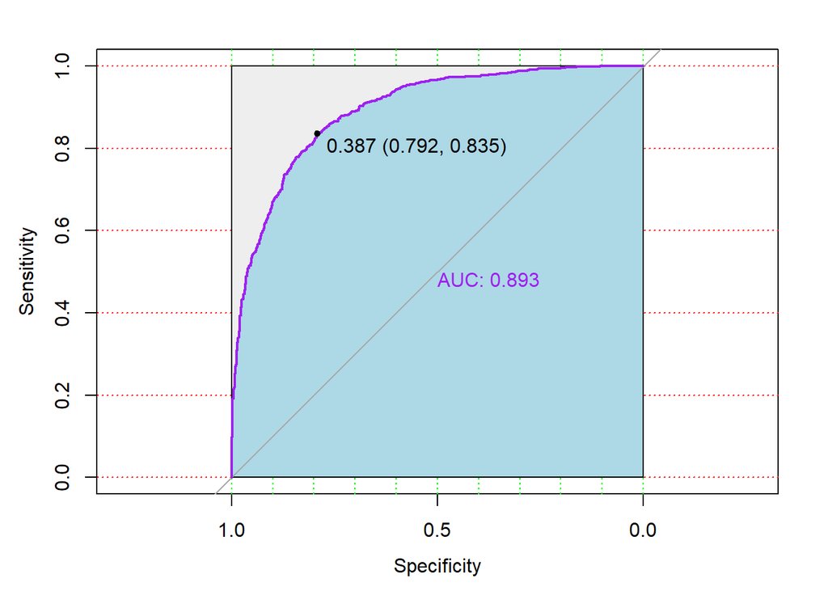

```r
plot.roc(datasetTest_2c$Type, probability[,2],col="purple", print.auc = TRUE,  auc.polygon=TRUE, grid=c(0.1, 0.2),
         grid.col=c("green", "red"), max.auc.polygon=TRUE,
         auc.polygon.col="lightblue", print.thres=TRUE)
```

When the AUC is bigger, the better, in our case our AUC is around 90%,so we can affirm the model is quite good. We can see that the area under the curve is big so we could say that our models are good. When the ROC curve goes more to the upper left corner, it means it is a perfect classification (AUC = 1). At the opposite side, the down right corner is a bad classification (AUC = 0) and the line at the middle would be if we try a model which guess randomly.

## The Benchmark

```r
library(gbm)
library(neuralnet)
```

In this case because we have many predictors, we will apply the penalized logistic regression

Again we will use our 2-class data set. Later on I will apply this same method for my multiclass data set (3-class data set)

```r
ctrl <- trainControl(method = "cv", number = 5,
                     classProbs = TRUE,
                     verboseIter=T)

# We have many predictors, hence use penalized logistic regression

lrFit <- train(Type ~ .,
               method = "glmnet",
               tuneGrid = expand.grid(alpha = seq(0, 1, 0.1), lambda = seq(0, .1, 0.02)),
               metric = "Kappa",
               data = auxtrain_2c,
               preProcess = c("center", "scale"),
               trControl = ctrl)
print(lrFit)
```

```
## glmnet
##
## 9162 samples
##    9 predictor
##    2 classes: 'Average', 'Elite'
##
## Pre-processing: centered (9), scaled (9)
## Resampling: Cross-Validated (5 fold)
## Summary of sample sizes: 7330, 7331, 7329, 7329, 7329
## Resampling results across tuning parameters:
##
##   alpha  lambda  Accuracy   Kappa
##   0.0    0.00    0.8316962  0.6639984
##   0.0    0.02    0.8316962  0.6639984
##   0.0    0.04    0.8268935  0.6544265
##   0.0    0.06    0.8201270  0.6409876
##   0.0    0.08    0.8179445  0.6366681
##   0.0    0.10    0.8148887  0.6306074
##   0.1    0.00    0.9317832  0.8636029
##   0.1    0.02    0.8368262  0.6742282
##   0.1    0.04    0.8258028  0.6522793
##   0.1    0.06    0.8185990  0.6379630
##   0.1    0.08    0.8149970  0.6308029
##   0.1    0.10    0.8132513  0.6273662
##   0.2    0.00    0.9419334  0.8838809
##   0.2    0.02    0.8373720  0.6753225
##   0.2    0.04    0.8236200  0.6479318
##   0.2    0.06    0.8175081  0.6357802
##   0.2    0.08    0.8142339  0.6292887
##   0.2    0.10    0.8103047  0.6214982
##   0.3    0.00    0.9469542  0.8939155
##   0.3    0.02    0.8379175  0.6763995
##   0.3    0.04    0.8220922  0.6448945
##   0.3    0.06    0.8152161  0.6312293
##   0.3    0.08    0.8109592  0.6227730
##   0.3    0.10    0.8081219  0.6171507
##   0.4    0.00    0.9488100  0.8976173
##   0.4    0.02    0.8362804  0.6731415
##   0.4    0.04    0.8210003  0.6427272
##   0.4    0.06    0.8120508  0.6249275
```

[output cut: 26 more lines]

```
##   0.9    0.00    0.9532852  0.9065523
##   0.9    0.02    0.8429390  0.6864273
##   0.9    0.04    0.8121600  0.6251359
##   0.9    0.06    0.7992802  0.5993129
##   0.9    0.08    0.7946955  0.5902449
##   0.9    0.10    0.7870550  0.5750972
##   1.0    0.00    0.9553592  0.9106978
##   1.0    0.02    0.8487244  0.6979443
##   1.0    0.04    0.8110683  0.6229430
##   1.0    0.06    0.7982978  0.5973662
##   1.0    0.08    0.7903294  0.5815750
##   1.0    0.10    0.7812699  0.5636519
##
## Kappa was used to select the optimal model using the largest value.
## The final values used for the model were alpha = 1 and lambda = 0.
```

```r
lrPred = predict(lrFit, auxtest_2c)
confusionMatrix(lrPred, auxtest_2c$Type)
```

```
## Confusion Matrix and Statistics
##
##           Reference
## Prediction Average Elite
##    Average    1083    49
##    Elite        40  1117
##
##                Accuracy : 0.9611
##                  95% CI : (0.9524, 0.9687)
##     No Information Rate : 0.5094
##     P-Value [Acc > NIR] : <2e-16
##
##                   Kappa : 0.9222
##
##  Mcnemar's Test P-Value : 0.3964
##
##             Sensitivity : 0.9644
##             Specificity : 0.9580
##          Pos Pred Value : 0.9567
##          Neg Pred Value : 0.9654
##              Prevalence : 0.4906
##          Detection Rate : 0.4731
##    Detection Prevalence : 0.4945
##       Balanced Accuracy : 0.9612
##
##        'Positive' Class : Average
##
```

We obtained an accuracy of around 95% which is almost a perfect classification. We must pay attetion in order to avoid over fitting

## Variable Importance

Now we can plot the importance of each variable for the model and see which variables have the most impact

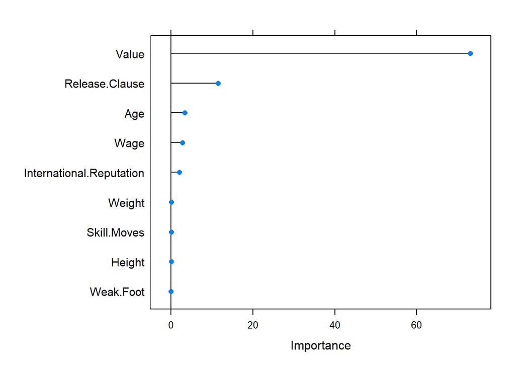

```r
lr_imp <- varImp(lrFit, scale = F)
plot(lr_imp, scales = list(y = list(cex = .95)))
```

We can clearly see that the variable Value is the most important in our model, followed by the Release Clause variable. The rest of the variables are less important comparted to Value.

## We can again plot the ROC Curve

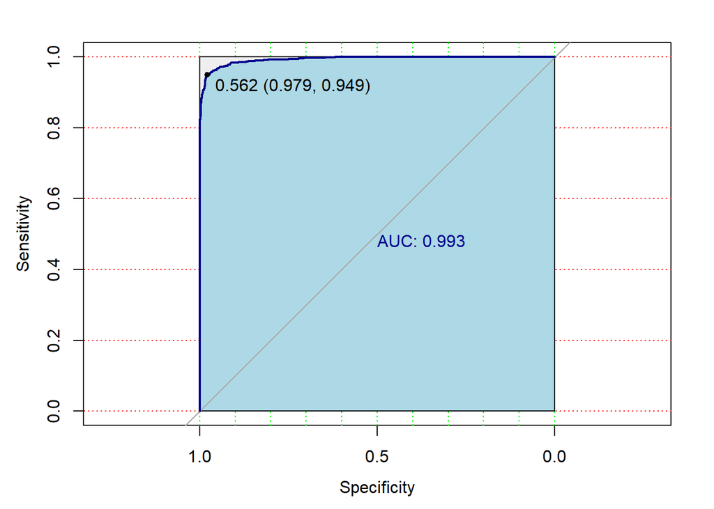

```r
library(pROC)
lrProb = predict(lrFit, auxtest_2c, type="prob")

plot.roc(auxtest_2c$Type, lrProb[,2],col="darkblue", print.auc = TRUE,  auc.polygon=TRUE, grid=c(0.1, 0.2),
         grid.col=c("green", "red"), max.auc.polygon=TRUE,
         auc.polygon.col="lightblue", print.thres=TRUE)
```

Additionally, we could plot the ROC Curve related to other important variables

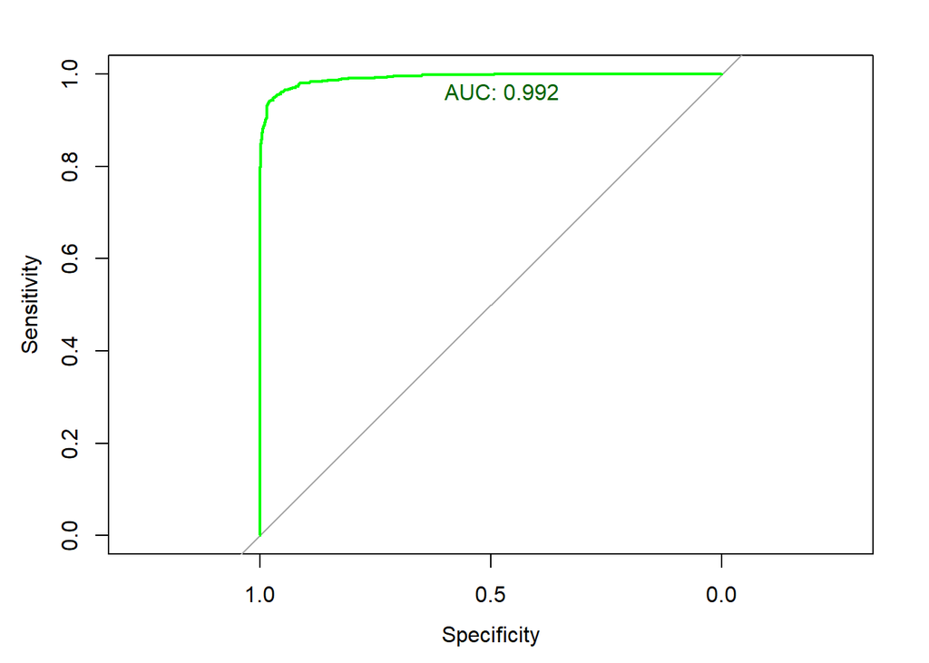

```r
plot.roc(auxtest_2c$Type[auxtest_2c$International.Reputation == 1], lrProb[auxtest_2c$International.Reputation == 1,2],print.auc = TRUE, col = "green", print.auc.col = "darkgreen",print.auc.y = 0.98, print.auc.x = 0.6)
```

```r
threshold = 0.4
lrProb = predict(lrFit, auxtest_2c, type="prob")
lrPred = rep("Average", nrow(auxtest_2c))
lrPred[which(lrProb[,2] > threshold)] = "Elite"
confusionMatrix(factor(lrPred), auxtest_2c$Type)
```

```
## Confusion Matrix and Statistics
##
##           Reference
## Prediction Average Elite
##    Average    1069    40
##    Elite        54  1126
##
##                Accuracy : 0.9589
##                  95% CI : (0.95, 0.9667)
##     No Information Rate : 0.5094
##     P-Value [Acc > NIR] : <2e-16
##
##                   Kappa : 0.9178
##
##  Mcnemar's Test P-Value : 0.18
##
##             Sensitivity : 0.9519
##             Specificity : 0.9657
##          Pos Pred Value : 0.9639
##          Neg Pred Value : 0.9542
##              Prevalence : 0.4906
##          Detection Rate : 0.4670
##    Detection Prevalence : 0.4845
##       Balanced Accuracy : 0.9588
##
##        'Positive' Class : Average
##
```

Again, we obtain a 95% of accuracy which is great.

## Cost-sensitive learning

In order to apply this the cost-sensitive learning method I must have a cost unit depending on the cost of predicting a true positive, false positive, true negative and false negative. Because I want to apply the cost-sensitive learning I decided to assume that my unit cost will be equivalent to the unit cost employed in the case study “Customer Analytics”, which the unit cost is 0xTN + 100xFP + 500xFN + 140xTP where: TN = True Negatives FP = False Positives FN = False Negatives TP = True Positives

In this way the cost matrix will be something similar to:

predicted no | predicted yes

no 0 100

yes 500 140

As I said before, I will use as my cost.unit vector the one that the professor used in his case study assuming the cost will be equivalent. In this way I can show how the cost-sensitive learning could be applied to my work.

Firstly, we create the cost unit vector

```r
cost.unit <- c(0, 100, 500, 140)
```

## Cost of Naive classifier

```r
CM = confusionMatrix(factor(lrPred), auxtest_2c$Type)$table
cost = sum(as.vector(CM)*cost.unit)/sum(CM)
cost
```

```
## [1] 79.96505
```

## Cost-sensitive classifier (expert level)

```r
cost.i = matrix(NA, nrow = 100, ncol = 10)
# 20 replicates for training/testing sets for each of the 10 values of threshold

j <- 0
for (threshold in seq(0.05,0.5,0.05)){

  j <- j + 1
  cat(j)
  for(i in 1:100){

    # partition data intro training (75%) and testing sets (25%)
    d <- createDataPartition(auxtrain_2c$Type, p = 0.8, list = FALSE)
    # select training sample

    train <- aux_2c[d,]
    test  <- aux_2c[-d,]

    lrFit <- train(Type ~ ., data=auxtrain_2c, method = "glmnet",
                   tuneGrid = data.frame(alpha = 0.3, lambda = 0), preProcess = c("center", "scale"),
                   trControl = trainControl(method = "none", classProbs = TRUE))

    lrProb = predict(lrFit, auxtest_2c, type="prob")
    lrPred = rep("Average", nrow(auxtest_2c))
    lrPred[which(lrProb[,2] > threshold)] = "Elite"

    CM = confusionMatrix(factor(lrPred), auxtest_2c$Type)$table
    cost = sum(as.vector(CM)*cost.unit)/sum(CM)
    cost

    cost.i[i,j] <- cost

  }
}
```

```
## 12345678910
```

```r
#12345678910
```

Now lets find the optimal threshold

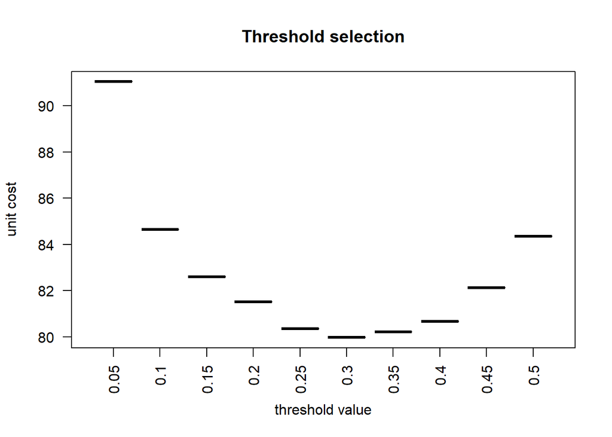

```r
# Threshold optimization:
boxplot(cost.i, main = "Threshold selection",
        ylab = "unit cost",
        xlab = "threshold value",
        names = seq(0.05,0.5,0.05),col="royalblue2",las=2)
```

We can see in the graph that the value of the threshold in order to be reasonable should be around 0.3

```r
apply(cost.i, 2, median)
```

```
##  [1] 91.04412 84.64832 82.59502 81.52031 80.35824 79.97379 80.20970 80.66405
##  [9] 82.12320 84.34251
```

And to end, our final prediction would be:

```r
threshold = 0.3
lrFit <- train(Type ~ ., data= auxtrain_2c, method = "glmnet",
               tuneGrid = data.frame(alpha = 0.3, lambda = 0), preProcess = c("center", "scale"),
               trControl = trainControl(method = "none", classProbs = TRUE))
lrProb = predict(lrFit, auxtest_2c, type="prob")
lrPred = rep("Average", nrow(auxtest_2c))
lrPred[which(lrProb[,2] > threshold)] = "Elite"
CM = confusionMatrix(factor(lrPred), auxtest_2c$Type)$table
cost = sum(as.vector(CM)*cost.unit)/sum(CM)
cost
```

```
## [1] 79.97379
```

## Risk learning

There are players which wage is higher than others. For instance, it is risky to pay a high wage to a player which do not belongs to the elite which cannot generates what he is getting paid.

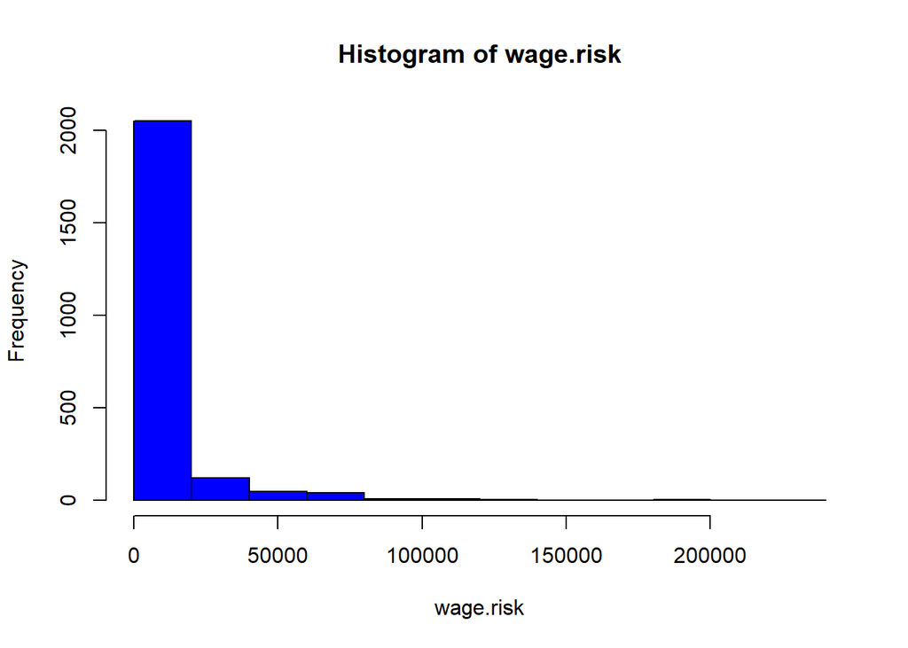

```r
wage.risk = auxtest_2c$Wage*lrProb[,2]
hist(wage.risk, col= "blue")
```

We should be worried about players with a wage higher than 10^5 €

```r
sum(wage.risk>10^5)/length(wage.risk)
```

```
## [1] 0.00873744
```

Approximately 1% of footballers would have this high wages

```r
sort.risk = sort(wage.risk,decreasing=T,index.return=T)
```

```r
# Most risky positions:
head(sort.risk$x)
```

```
## [1] 230000 210000 200000 200000 195000 160000
```

```r
# Most risky footballers:
head(sort.risk$ix)
```

```
## [1]   2 981  15  74 135  19
```

# Machine Learning Tools

## Decision Trees

Firstly, a brief description of what is a decision tree. It is a flow-chart-like structure in which each internal node represents a test on a feature and it makes predictions based on how a previous set of questions were answered. It is important to mention about the hyper-parameters

Definitions: minsplit= minimum number of observations in a node before before a split cp= degree of complexity, the smaller the more branches maxdepth= maximum depth of any node of the final tree

```r
library(rpart)

# Here we decide the hyper-parameters
control = rpart.control(minsplit = 30, maxdepth = 10, cp=0.01)
```

```r
model = Type ~.
dtFit <- rpart(model, data=auxtrain, method = "class", control = control)
summary(dtFit)
```

```
## Call:
## rpart(formula = model, data = auxtrain, method = "class", control = control)
##   n= 9162
##
##           CP nsplit rel error    xerror        xstd
## 1 0.43567154      0 1.0000000 1.0000000 0.007554928
## 2 0.26562500      1 0.5643285 0.5643285 0.007684080
## 3 0.04355053      2 0.2987035 0.2987035 0.006317677
## 4 0.04122340      3 0.2551529 0.2559840 0.005949656
## 5 0.03557181      4 0.2139295 0.2285572 0.005682422
## 6 0.01213431      5 0.1783577 0.1783577 0.005116162
## 7 0.01188497      6 0.1662234 0.1640625 0.004932868
## 8 0.01000000      8 0.1424535 0.1476064 0.004707185
##
## Variable importance
##                    Value           Release.Clause                     Wage
##                       33                       26                       17
##                      Age              Skill.Moves International.Reputation
##                       13                        5                        4
##                Weak.Foot
##                        2
##
## Node number 1: 9162 observations,    complexity param=0.4356715
##   predicted class=Silver  expected loss=0.6566252  P(node) =1
##     class counts:  3048  2968  3146
##    probabilities: 0.333 0.324 0.343
##   left son=2 (3888 obs) right son=3 (5274 obs)
##   Primary splits:
##       Value          < 537500  to the left,  improve=1921.2730, (0 missing)
##       Wage           < 4500    to the left,  improve=1678.5580, (0 missing)
##       Release.Clause < 1250000 to the left,  improve=1678.1810, (0 missing)
##       Age            < 21.5    to the left,  improve= 904.5329, (0 missing)
##       Skill.Moves    < 2.5     to the left,  improve= 598.4550, (0 missing)
##   Surrogate splits:
##       Release.Clause < 1150000 to the left,  agree=0.913, adj=0.795, (0 split)
##       Wage           < 1500    to the left,  agree=0.743, adj=0.395, (0 split)
##       Age            < 20.5    to the left,  agree=0.678, adj=0.242, (0 split)
##       Skill.Moves    < 2.5     to the left,  agree=0.660, adj=0.200, (0 split)
##       Weak.Foot      < 2.5     to the left,  agree=0.601, adj=0.060, (0 split)
##
```

[output cut: 155 more lines]

```
##       Wage                     < 6500    to the right, agree=0.827, adj=0.275, (0 split)
##       International.Reputation < 1.5     to the right, agree=0.803, adj=0.174, (0 split)
##       Height                   < 162.5   to the left,  agree=0.765, adj=0.018, (0 split)
##       Weight                   < 88.5    to the right, agree=0.765, adj=0.018, (0 split)
##       Release.Clause           < 703500  to the left,  agree=0.765, adj=0.018, (0 split)
##
## Node number 58: 109 observations
##   predicted class=Gold    expected loss=0.1651376  P(node) =0.01189697
##     class counts:     0    91    18
##    probabilities: 0.000 0.835 0.165
##
## Node number 59: 347 observations
##   predicted class=Silver  expected loss=0.08645533  P(node) =0.03787383
##     class counts:     0    30   317
##    probabilities: 0.000 0.086 0.914
```

For each node in the tree, the number of examples reaching the decision point is listed

But it is better if we plot and visualize the computed decision tree.

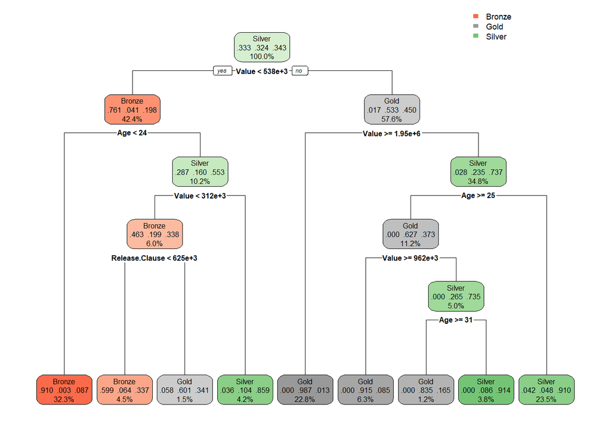

```r
library(rpart.plot)
rpart.plot(dtFit, digits=3)
```

It can be appreciated that each node shows the predict class, the predicted probability of each class and the percentage of observations in each node. Also it is important to mention that due to pruning other nodes have been removed. In our case, it took into consideration variables such as Value or Age in order to predict the overall of the player.

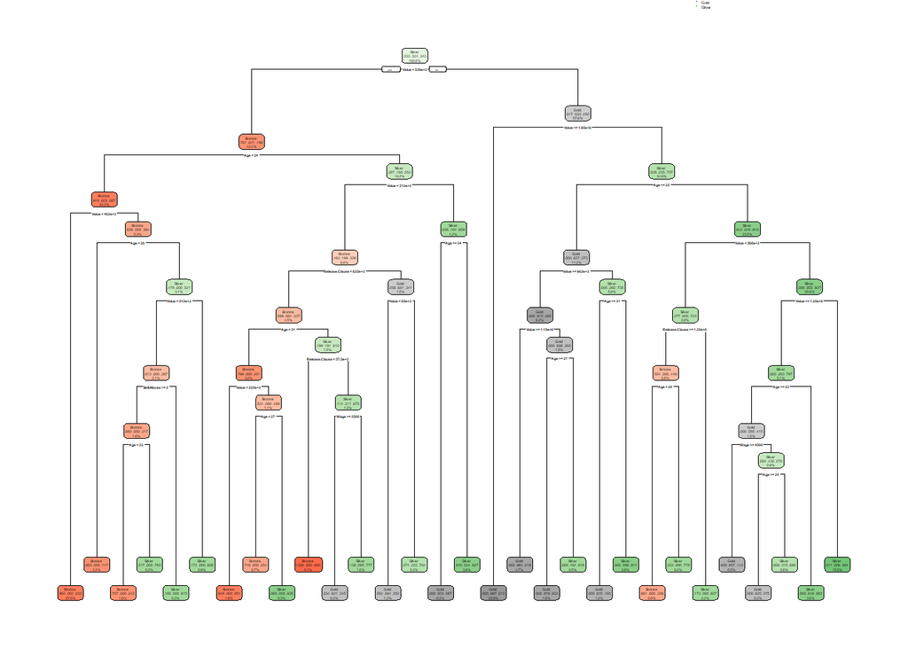

```r
control = rpart.control(minsplit = 40, maxdepth = 12, cp=0.001)
dtFit <- rpart(model, data=auxtrain, method = "class", control = control)

rpart.plot(dtFit, digits = 3)
```

And this is the way to obtain our full decision tree, however it is quite PC-demanding and even there could be some overplotting.

If we work with our bivariable classification data set and plot its decision tree

```r
control = rpart.control(minsplit = 30, maxdepth = 10, cp=0.01)
model = Type ~.
dtFit <- rpart(model, data=auxtrain_2c, method = "class", control = control)
summary(dtFit)
```

```
## Call:
## rpart(formula = model, data = auxtrain_2c, method = "class",
##     control = control)
##   n= 9162
##
##           CP nsplit  rel error     xerror        xstd
## 1 0.76234980      0 1.00000000 1.00000000 0.010647649
## 2 0.07098353      1 0.23765020 0.23765020 0.006835008
## 3 0.06764575      2 0.16666667 0.19737428 0.006298217
## 4 0.01490877      3 0.09902092 0.10280374 0.004660713
## 5 0.01000000      4 0.08411215 0.09034268 0.004383164
##
## Variable importance
##                    Value           Release.Clause                     Wage
##                       31                       26                       17
##                      Age              Skill.Moves International.Reputation
##                       12                        9                        4
##
## Node number 1: 9162 observations,    complexity param=0.7623498
##   predicted class=Elite    expected loss=0.4905043  P(node) =1
##     class counts:  4494  4668
##    probabilities: 0.491 0.509
##   left son=2 (5474 obs) right son=3 (3688 obs)
##   Primary splits:
##       Value          < 962500  to the left,  improve=2827.5090, (0 missing)
##       Release.Clause < 1550000 to the left,  improve=2395.0770, (0 missing)
##       Wage           < 3500    to the left,  improve=1576.7030, (0 missing)
##       Age            < 21.5    to the left,  improve=1230.9360, (0 missing)
##       Skill.Moves    < 2.5     to the left,  improve= 720.4559, (0 missing)
##   Surrogate splits:
##       Release.Clause           < 1850000 to the left,  agree=0.921, adj=0.803, (0 split)
##       Wage                     < 3500    to the left,  agree=0.828, adj=0.574, (0 split)
##       Skill.Moves              < 2.5     to the left,  agree=0.720, adj=0.304, (0 split)
##       Age                      < 22.5    to the left,  agree=0.655, adj=0.143, (0 split)
##       International.Reputation < 1.5     to the left,  agree=0.649, adj=0.127, (0 split)
##
## Node number 2: 5474 observations,    complexity param=0.07098353
##   predicted class=Average  expected loss=0.1870661  P(node) =0.5974678
##     class counts:  4450  1024
##    probabilities: 0.813 0.187
```

[output cut: 59 more lines]

```
##
## Node number 11: 829 observations
##   predicted class=Elite    expected loss=0.1242461  P(node) =0.09048243
##     class counts:   103   726
##    probabilities: 0.124 0.876
##
## Node number 20: 457 observations
##   predicted class=Average  expected loss=0.0940919  P(node) =0.04987994
##     class counts:   414    43
##    probabilities: 0.906 0.094
##
## Node number 21: 201 observations
##   predicted class=Elite    expected loss=0.3333333  P(node) =0.02193844
##     class counts:    67   134
##    probabilities: 0.333 0.667
```

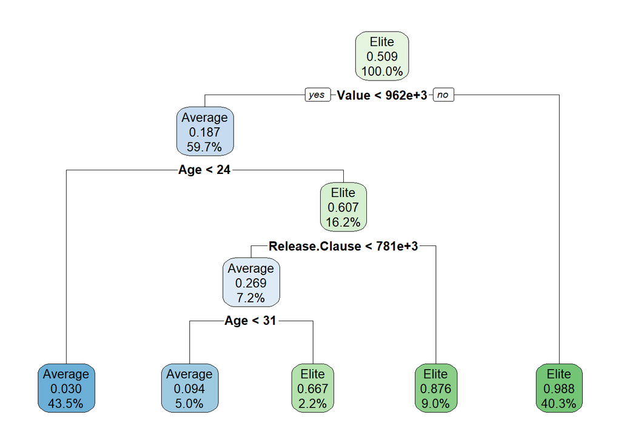

```r
rpart.plot(dtFit, digits=3)
```

And if we are interested in the full decision tree..

```r
control = rpart.control(minsplit = 40, maxdepth = 12, cp=0.001)
dtFit <- rpart(model, data=auxtrain_2c, method = "class", control = control)
summary(dtFit)
```

```
## Call:
## rpart(formula = model, data = auxtrain_2c, method = "class",
##     control = control)
##   n= 9162
##
##             CP nsplit  rel error     xerror        xstd
## 1  0.762349800      0 1.00000000 1.00000000 0.010647649
## 2  0.070983534      1 0.23765020 0.23765020 0.006835008
## 3  0.067645750      2 0.16666667 0.16755674 0.005849806
## 4  0.014908767      3 0.09902092 0.10302626 0.004665487
## 5  0.005785492      4 0.08411215 0.08856253 0.004341747
## 6  0.002781486      5 0.07832666 0.08522474 0.004262788
## 7  0.002670227      8 0.06942590 0.07943925 0.004121645
## 8  0.001557632     10 0.06408545 0.07231865 0.003939725
## 9  0.001335113     13 0.05941255 0.06809079 0.003826937
## 10 0.001000000     14 0.05807744 0.06542056 0.003753689
##
## Variable importance
##                    Value           Release.Clause                     Wage
##                       31                       26                       17
##                      Age              Skill.Moves International.Reputation
##                       13                        9                        4
##
## Node number 1: 9162 observations,    complexity param=0.7623498
##   predicted class=Elite    expected loss=0.4905043  P(node) =1
##     class counts:  4494  4668
##    probabilities: 0.491 0.509
##   left son=2 (5474 obs) right son=3 (3688 obs)
##   Primary splits:
##       Value          < 962500  to the left,  improve=2827.5090, (0 missing)
##       Release.Clause < 1550000 to the left,  improve=2395.0770, (0 missing)
##       Wage           < 3500    to the left,  improve=1576.7030, (0 missing)
##       Age            < 21.5    to the left,  improve=1230.9360, (0 missing)
##       Skill.Moves    < 2.5     to the left,  improve= 720.4559, (0 missing)
##   Surrogate splits:
##       Release.Clause           < 1850000 to the left,  agree=0.921, adj=0.803, (0 split)
##       Wage                     < 3500    to the left,  agree=0.828, adj=0.574, (0 split)
##       Skill.Moves              < 2.5     to the left,  agree=0.720, adj=0.304, (0 split)
##       Age                      < 22.5    to the left,  agree=0.655, adj=0.143, (0 split)
##       International.Reputation < 1.5     to the left,  agree=0.649, adj=0.127, (0 split)
```

[output cut: 275 more lines]

```
##
## Node number 85: 26 observations
##   predicted class=Elite    expected loss=0.3846154  P(node) =0.002837808
##     class counts:    10    16
##    probabilities: 0.385 0.615
##
## Node number 88: 76 observations
##   predicted class=Average  expected loss=0.2368421  P(node) =0.008295132
##     class counts:    58    18
##    probabilities: 0.763 0.237
##
## Node number 89: 21 observations
##   predicted class=Elite    expected loss=0.1428571  P(node) =0.002292076
##     class counts:     3    18
##    probabilities: 0.143 0.857
```

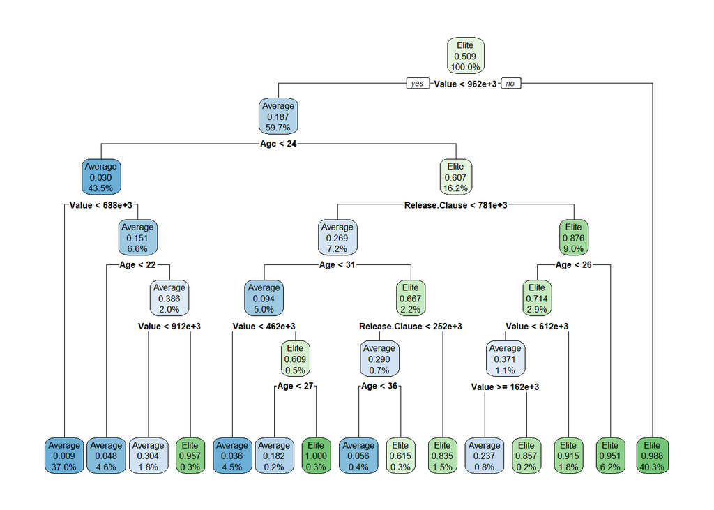

```r
rpart.plot(dtFit, digits = 3)
```

Now lets do the predictions to plot the confusion matrix in our 2-class categorical variable data set.

```r
dtPred <- predict(dtFit, auxtest_2c, type = "class")
dtProb <- predict(dtFit, auxtest_2c, type = "prob")
threshold = 0.2 # A threshold of 0.2 its acceptable
dtPred = rep("Average", nrow(auxtest_2c))
dtPred[which(dtProb[,2] > threshold)] = "Elite"
CM = confusionMatrix(factor(dtPred), auxtest_2c$Type)$table
CM
```

```
##           Reference
## Prediction Average Elite
##    Average    1062    29
##    Elite        61  1137
```

```r
confusionMatrix(factor(dtPred), auxtest_2c$Type)$overall[1]
```

```
##  Accuracy
## 0.9606815
```

```r
cost = sum(as.vector(CM)*cost.unit)/sum(CM)
cost
```

```
## [1] 78.54085
```

## Using Caret

For our multiclass data set:

```r
library(caret)

caret.fit <- train(model,
                   data = auxtrain,
                   method = "rpart",
                   control=rpart.control(minsplit = 40, maxdepth = 12),
                   trControl = trainControl(method = "cv", number = 5),
                   tuneLength=10)
caret.fit
```

```
## CART
##
## 9162 samples
##    9 predictor
##    3 classes: 'Bronze', 'Gold', 'Silver'
##
## No pre-processing
## Resampling: Cross-Validated (5 fold)
## Summary of sample sizes: 7329, 7330, 7330, 7330, 7329
## Resampling results across tuning parameters:
##
##   cp           Accuracy   Kappa
##   0.003102837  0.9133365  0.8699562
##   0.004321809  0.9088626  0.8632697
##   0.009308511  0.9022041  0.8532614
##   0.011884973  0.8954379  0.8430590
##   0.012134309  0.8938003  0.8405896
##   0.035571809  0.8624758  0.7936740
##   0.041223404  0.8379156  0.7568556
##   0.043550532  0.8271111  0.7405576
##   0.265625000  0.6968965  0.5479358
##   0.435671543  0.4566629  0.1777532
##
## Accuracy was used to select the optimal model using the largest value.
## The final value used for the model was cp = 0.003102837.
```

And in order to visualize it.

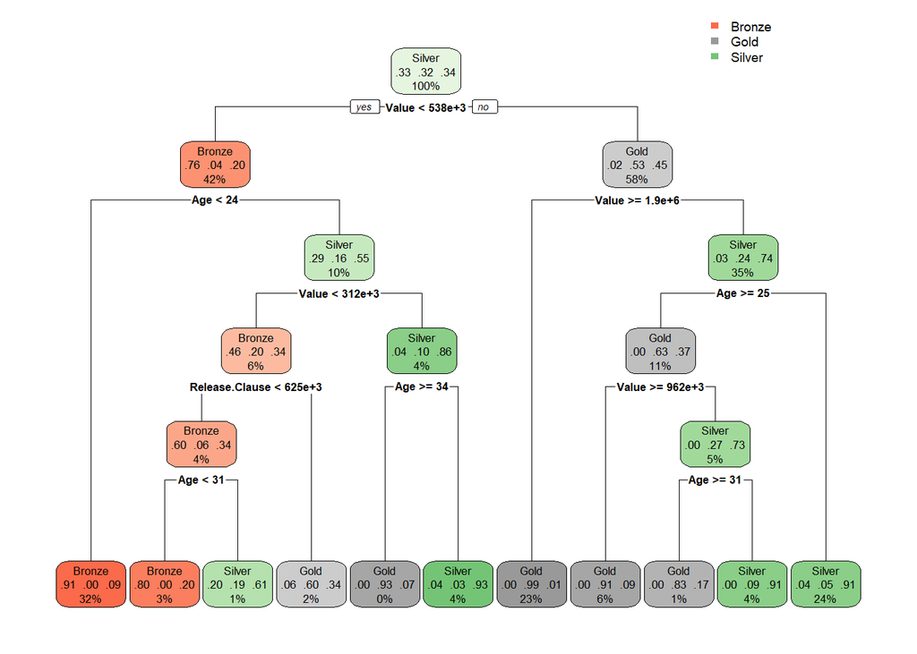

```r
rpart.plot(caret.fit$finalModel)
```

And for our bi variable classification data set and in order to compute the CM…

```r
caret.fit <- train(model,
                   data = auxtrain_2c,
                   method = "rpart",
                   control=rpart.control(minsplit = 40, maxdepth = 12),
                   trControl = trainControl(method = "cv", number = 5),
                   tuneLength=10)
caret.fit
```

```
## CART
##
## 9162 samples
##    9 predictor
##    2 classes: 'Average', 'Elite'
##
## No pre-processing
## Resampling: Cross-Validated (5 fold)
## Summary of sample sizes: 7329, 7329, 7330, 7331, 7329
## Resampling results across tuning parameters:
##
##   cp            Accuracy   Kappa
##   0.0009642486  0.9671462  0.9342780
##   0.0015576324  0.9652906  0.9305715
##   0.0016688919  0.9644173  0.9288271
##   0.0026702270  0.9625620  0.9251230
##   0.0027814864  0.9625620  0.9251230
##   0.0057854918  0.9571048  0.9141671
##   0.0149087672  0.9521925  0.9043742
##   0.0676457499  0.9359350  0.8717000
##   0.0709835336  0.8939085  0.7881650
##   0.7623497997  0.7326398  0.4581695
##
## Accuracy was used to select the optimal model using the largest value.
## The final value used for the model was cp = 0.0009642486.
```

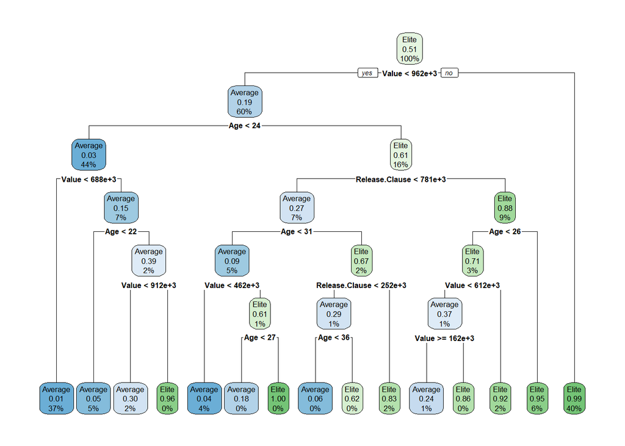

```r
rpart.plot(caret.fit$finalModel)
```

Predictions:

```r
dtProb <- predict(caret.fit, auxtest_2c, type = "prob")
threshold = 0.2
dtPred = rep("Average", nrow(auxtest_2c))
dtPred[which(dtProb[,2] > threshold)] = "Elite"
CM = confusionMatrix(factor(dtPred), auxtest_2c$Type)$table
CM
```

```
##           Reference
## Prediction Average Elite
##    Average    1062    29
##    Elite        61  1137
```

```r
confusionMatrix(factor(dtPred), auxtest_2c$Type)$overall[1]
```

```
##  Accuracy
## 0.9606815
```

```r
cost = sum(as.vector(CM)*cost.unit)/sum(CM)
cost
```

```
## [1] 78.54085
```

We obtain a very similar accuracy compared to the previous model not using Caret approach.

## Random Forest

A brief description of random forests would be an algorithm consisting of many decision trees, which we had already done it previously. Definitions: mtry: number of variables randomly sampled as candidates at each split ntree: number of trees to grow cutoff: cutoff probabilities in majority vote

We start by computing the random forest training model

```r
rf.train <- randomForest(Type ~., data= auxtrain,ntree=200,mtry=9,cutoff=c(0.33,0.33, 0.33),importance=TRUE, do.trace=T)
```

```
## ntree      OOB      1      2      3
##     1:   8.24%  8.24%  4.36% 11.93%
##     2:   8.46%  7.60%  4.14% 13.39%
##     3:   8.50%  7.73%  4.68% 12.81%
##     4:   8.06%  7.22%  4.37% 12.37%
##     5:   8.21%  7.08%  4.52% 12.77%
##     6:   7.77%  6.84%  4.23% 11.98%
##     7:   7.88%  6.90%  4.45% 12.07%
##     8:   7.78%  6.94%  4.52% 11.66%
##     9:   7.48%  6.50%  4.41% 11.34%
##    10:   7.26%  6.31%  4.25% 11.01%
##    11:   7.18%  5.96%  4.27% 11.11%
##    12:   7.02%  5.85%  4.19% 10.83%
##    13:   7.07%  6.04%  4.26% 10.72%
##    14:   6.94%  5.91%  4.15% 10.58%
```

[output cut: 186 more lines]

Predict and compute the Confusion Matrix

```r
rf.pred <- predict(rf.train, newdata=auxtest)
confusionMatrix(rf.pred, auxtest$Type)
```

```
## Confusion Matrix and Statistics
##
##           Reference
## Prediction Bronze Gold Silver
##     Bronze    728    0     55
##     Gold        1  707     18
##     Silver     33   34    713
##
## Overall Statistics
##
##                Accuracy : 0.9384
##                  95% CI : (0.9278, 0.9479)
##     No Information Rate : 0.3434
##     P-Value [Acc > NIR] : < 2.2e-16
##
##                   Kappa : 0.9076
##
##  Mcnemar's Test P-Value : 0.009645
##
## Statistics by Class:
##
##                      Class: Bronze Class: Gold Class: Silver
## Sensitivity                 0.9554      0.9541        0.9071
## Specificity                 0.9640      0.9877        0.9554
## Pos Pred Value              0.9298      0.9738        0.9141
## Neg Pred Value              0.9774      0.9782        0.9516
## Prevalence                  0.3329      0.3237        0.3434
## Detection Rate              0.3180      0.3089        0.3115
## Detection Prevalence        0.3421      0.3172        0.3408
## Balanced Accuracy           0.9597      0.9709        0.9313
```

And for the bivariable classification

```r
rf.train <- randomForest(Type ~., data= auxtrain_2c,ntree=200,mtry=8,cutoff=c(0.75,0.25),importance=TRUE, do.trace=T)
```

```
## ntree      OOB      1      2
##     1:   3.57%  3.63%  3.51%
##     2:   3.82%  4.66%  3.01%
##     3:   3.85%  5.09%  2.66%
##     4:   3.93%  5.41%  2.53%
##     5:   3.70%  5.30%  2.18%
##     6:   3.69%  5.53%  1.91%
##     7:   3.78%  5.68%  1.96%
##     8:   3.69%  5.59%  1.86%
##     9:   3.52%  5.36%  1.74%
##    10:   3.57%  5.57%  1.64%
##    11:   3.49%  5.44%  1.62%
##    12:   3.46%  5.47%  1.53%
##    13:   3.48%  5.37%  1.65%
##    14:   3.53%  5.48%  1.65%
```

[output cut: 186 more lines]

```r
rf.pred <- predict(rf.train, newdata=auxtest_2c)
confusionMatrix(rf.pred, auxtest_2c$Type)
```

```
## Confusion Matrix and Statistics
##
##           Reference
## Prediction Average Elite
##    Average    1077    12
##    Elite        46  1154
##
##                Accuracy : 0.9747
##                  95% CI : (0.9674, 0.9807)
##     No Information Rate : 0.5094
##     P-Value [Acc > NIR] : < 2.2e-16
##
##                   Kappa : 0.9493
##
##  Mcnemar's Test P-Value : 1.47e-05
##
##             Sensitivity : 0.9590
##             Specificity : 0.9897
##          Pos Pred Value : 0.9890
##          Neg Pred Value : 0.9617
##              Prevalence : 0.4906
##          Detection Rate : 0.4705
##    Detection Prevalence : 0.4758
##       Balanced Accuracy : 0.9744
##
##        'Positive' Class : Average
##
```

Now it would be interesting to optimize the hyper-parameters, in order to do that:

We must define a specific function:

```r
CostFunction <- function(data, lev = NULL, model = NULL)
{
  y.pred = data$pred
  y.true = data$obs
  CM = confusionMatrix(y.pred, y.true)$table
  out = sum(as.vector(CM)*cost.unit)/sum(CM)
  names(out) <- c("CostFunction")
  out
}
```

Now if we include this function in the Caret Control:

```r
ctrl <- trainControl(method = "cv", number = 5,
                     classProbs = TRUE,
                     summaryFunction = CostFunction,
                     verboseIter=T)
```

For instance, this would be the cost with the previous prediction

```r
CostFunction(data = data.frame(pred  = rf.pred, obs = auxtest_2c$Type))
```

```
## CostFunction
##     75.21188
```

Now we must train a Random Forest with a specific metric using Caret

```r
rf.train <- train(Type ~.,
                  method = "rf",
                  data = auxtrain_2c,
                  preProcess = c("center", "scale"),
                  ntree = 200,
                  cutoff=c(0.7,0.3),
                  tuneGrid = expand.grid(mtry=c(4,5,6)),
                  metric = "CostFunction",
                  maximize = F,
                  trControl = ctrl)
```

And now for the variable importance

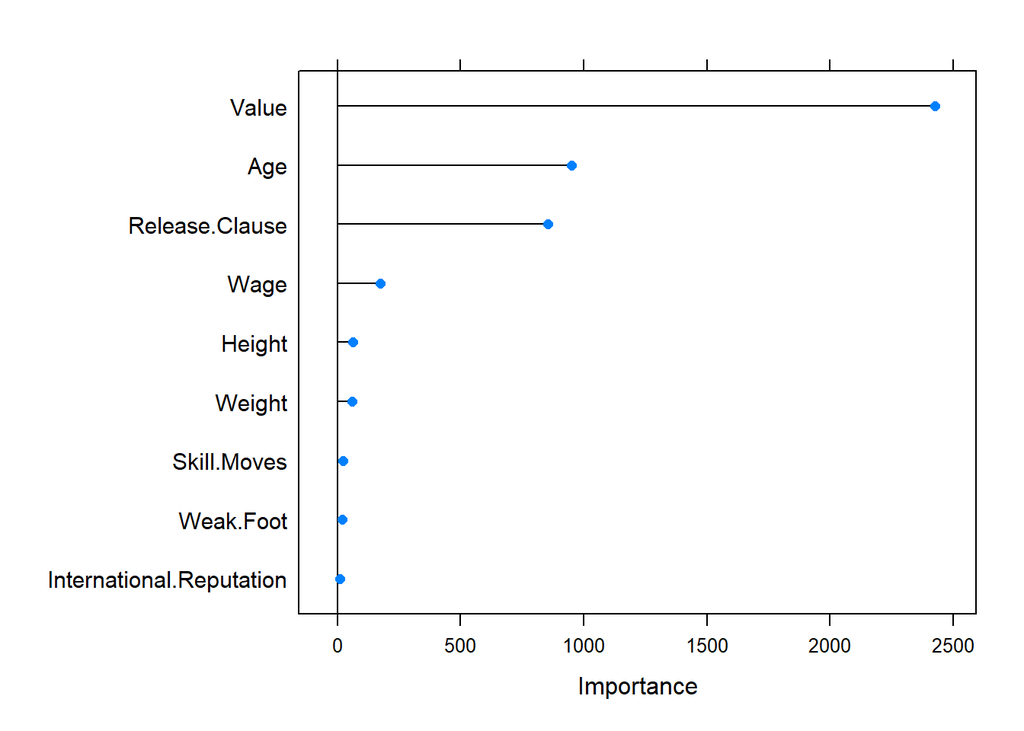

```r
rf_imp <- varImp(rf.train, scale = F)
plot(rf_imp, scales = list(y = list(cex = .95)))
```

We obtain that there are 3 variables which are the most importants, which are in first place the Value, secondly the age of the player and in third place the release clause. The other variables are much less important compared to those 3 (especially Value, which is super important)

```r
rfPred = predict(rf.train, newdata=auxtest_2c)
CM = confusionMatrix(factor(rfPred), auxtest_2c$Type)$table
CM
```

```
##           Reference
## Prediction Average Elite
##    Average    1085    14
##    Elite        38  1152
```

```r
confusionMatrix(factor(rfPred), auxtest_2c$Type)$overall[1]
```

```
##  Accuracy
## 0.9772827
```

```r
cost = sum(as.vector(CM)*cost.unit)/sum(CM)
cost
```

```
## [1] 75.17693
```

It is important to mention that sometimes the hyper-parameters in the Machine Learning tools are less important that the threshold in the Bayes rule

```r
threshold = 0.3
rfProb = predict(rf.train, newdata=auxtest_2c, type="prob")
rfPred = rep("Average", nrow(auxtest_2c))
rfPred[which(rfProb[,2] > threshold)] = "Elite"
CM = confusionMatrix(factor(rfPred), auxtest_2c$Type)$table
CM
```

```
##           Reference
## Prediction Average Elite
##    Average    1085    14
##    Elite        38  1152
```

```r
cost = sum(as.vector(CM)*cost.unit)/sum(CM)
cost
```

```
## [1] 75.17693
```

## Gradient Boosting

We will use our bivariable classification data set

```r
GBM.train <- gbm(ifelse(auxtrain_2c$Type=="Average",0,1) ~., data=auxtrain_2c, distribution= "bernoulli",n.trees=250,shrinkage = 0.01,interaction.depth=2,n.minobsinnode = 8)
```

Lets compute the predictions

```r
threshold = 0.2
gbmProb = predict(GBM.train, newdata=auxtest_2c, n.trees=250, type="response")
gbmPred = rep("Average", nrow(auxtest_2c))
gbmPred[which(gbmProb > threshold)] = "Elite"
CM = confusionMatrix(factor(gbmPred), auxtest_2c$Type)$table
CM
```

```
##           Reference
## Prediction Average Elite
##    Average     889    12
##    Elite       234  1154
```

```r
confusionMatrix(factor(gbmPred), auxtest_2c$Type)$overall[1]
```

```
##  Accuracy
## 0.8925295
```

```r
cost = sum(as.vector(CM)*cost.unit)/sum(CM)
cost
```

```
## [1] 83.42508
```

Maybe we could try now the xgboost with Caret, so firstly we will define a grid for the hyper-parameters.

```r
xgb_grid = expand.grid(
  nrounds = c(500,1000),
  eta = c(0.01, 0.001), # c(0.01,0.05,0.1)
  max_depth = c(2, 4, 6),
  gamma = 1,
  colsample_bytree = c(0.2, 0.4),
  min_child_weight = c(1,5),
  subsample = 1
)
```

Now its time to train

```r
xgb.train = train(Type ~ .,  data=auxtrain_2c,
                  trControl = ctrl,
                  metric="CostFunction",
                  maximize = F,
                  tuneGrid = xgb_grid,
                  preProcess = c("center", "scale"),
                  method = "xgbTree"
)
```

[output not shown]

[output cut: 186 more lines]

[output not shown]

Variable importance

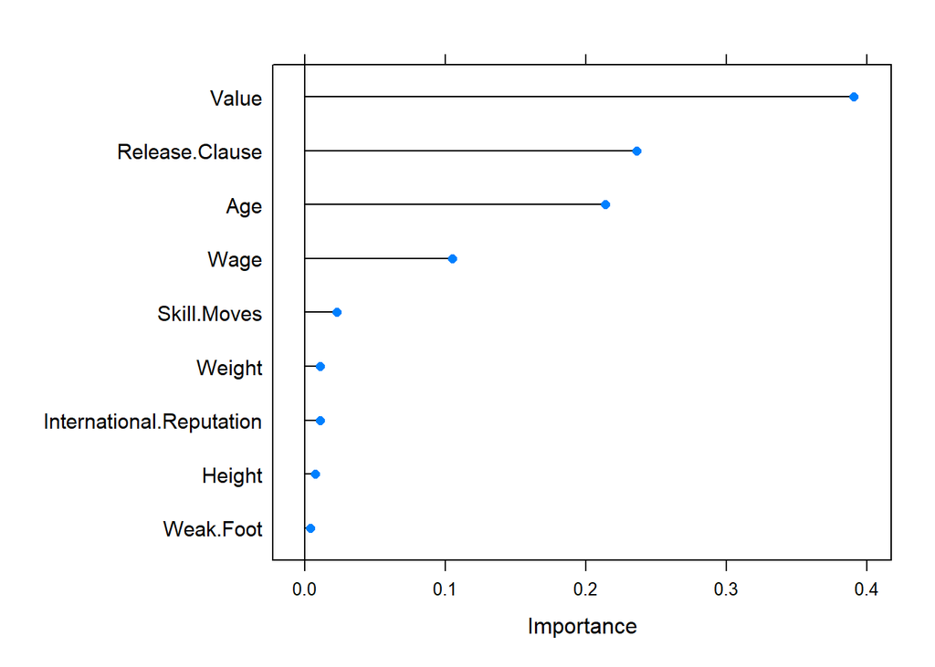

```r
xgb_imp <- varImp(xgb.train, scale = F)
plot(xgb_imp, scales = list(y = list(cex = .95)))
```

Once again, we can see that the variables Value, Release clause and age are the most important. However, it is true that now others variables such as Wage or Skill moves are not so insignificant as before, and now value variable has decreased its importance.

Prediction and cost

```r
threshold = 0.2
xgbProb = predict(xgb.train, newdata=auxtest_2c, type="prob")
xgbPred = rep("Average", nrow(auxtest_2c))
xgbPred[which(xgbProb[,2] > threshold)] = "Elite"
CM = confusionMatrix(factor(xgbPred), auxtest_2c$Type)$table
CM
```

```
##           Reference
## Prediction Average Elite
##    Average    1047     9
##    Elite        76  1157
```

```r
confusionMatrix(factor(xgbPred), auxtest_2c$Type)$overall[1]
```

```
##  Accuracy
## 0.9628659
```

```r
cost = sum(as.vector(CM)*cost.unit)/sum(CM)
cost
```

```
## [1] 76.05068
```

## Subsampling Techniques

```r
ctrl$sampling <- "up"

rf.train <- train(Type ~.,
                  method = "rf",
                  data = auxtrain_2c,
                  preProcess = c("center", "scale"),
                  ntree = 200,
                  cutoff=c(0.7,0.3),
                  tuneGrid = expand.grid(mtry=c(4,5,6)),
                  importance=TRUE,
                  metric = "CostFunction",
                  maximize = F,
                  trControl = ctrl)
```

Prediction and cost

```r
threshold = 0.2
rfProb = predict(rf.train, newdata=auxtest_2c, type="prob")
rfPred = rep("Average", nrow(auxtest_2c))
rfPred[which(rfProb[,2] > threshold)] = "Elite"
CM = confusionMatrix(factor(rfPred), auxtest_2c$Type)$table
cost = sum(as.vector(CM)*cost.unit)/sum(CM)
cost
```

```
## [1] 74.99345
```

Not quite different…

## Basic Ensembles

Ensemble learning is based on combining the best classifiers and form a meta-classifier

We will start by creating an ensemble for classification with the mode function for our bivariable classification data set.

```r
mode <- function(v) {
  uniqv <- unique(v)
  uniqv[which.max(tabulate(match(v, uniqv)))]
}
```

Now lets see the accuracy an the CM

```r
ensemble.pred = apply(data.frame(lrPred,xgbPred, lrProb), 1, mode)
CM = confusionMatrix(factor(ensemble.pred), auxtest_2c$Type)$table
CM
```

```
##           Reference
## Prediction Average Elite
##    Average    1004    22
##    Elite       119  1144
```

```r
confusionMatrix(factor(ensemble.pred), auxtest_2c$Type)$overall[1]
```

```
## Accuracy
## 0.938401
```

```r
cost = sum(as.vector(CM)*cost.unit)/sum(CM)
cost
```

```
## [1] 79.97379
```

# REGRESSION

Now we will just focus on numerical variables.

For that reason, I will create a new data set in which it only contains numerical variables using an auxiliar data set in order to do not lose the information of the original data set I have decided to split again the data set but now instead of a 80%, it will be a 75% (the main reason is just to explore new possible results).

```r
aux = copy # We stored the original data set in which the variable Overall is numerical in order to use it now


# Lets remove the non-numerical or categorical which will not be necessary and convert some variables into categoricals
aux$Name = NULL
aux$Nationality = NULL
aux$Club = NULL
aux$Work.Rate = NULL

aux$Real.Face =  as.factor(aux$Real.Face)
levels(aux$Real.Face)
```

```
## [1] "FALSE" "TRUE"
```

```r
aux$Real.Face = factor(aux$Real.Face, levels = c("FALSE", "TRUE"), labels = c(0,1))

aux$Preferred.Foot = as.factor(aux$Preferred.Foot)
levels(aux$Preferred.Foot)
```

```
## [1] "Left"  "Right"
```

```r
aux$Preferred.Foot = factor(aux$Preferred.Foot, levels = c("Left", "Right"), labels = c(1,2))



# Now lets split the data into 75-25
in_train <- createDataPartition(aux$Overall, p = 0.75, list = FALSE)  # 75% for training
training <- aux[ in_train,]
testing <- aux[-in_train,]

nrow(training)
```

```
## [1] 8591
```

```r
nrow(testing)
```

```
## [1] 2860
```

```r
nrow(training) + nrow(testing) == nrow(dataset)
```

```
## [1] TRUE
```

## Simple and multiple regression models

We could start by watching the correlation with our main numerical variable

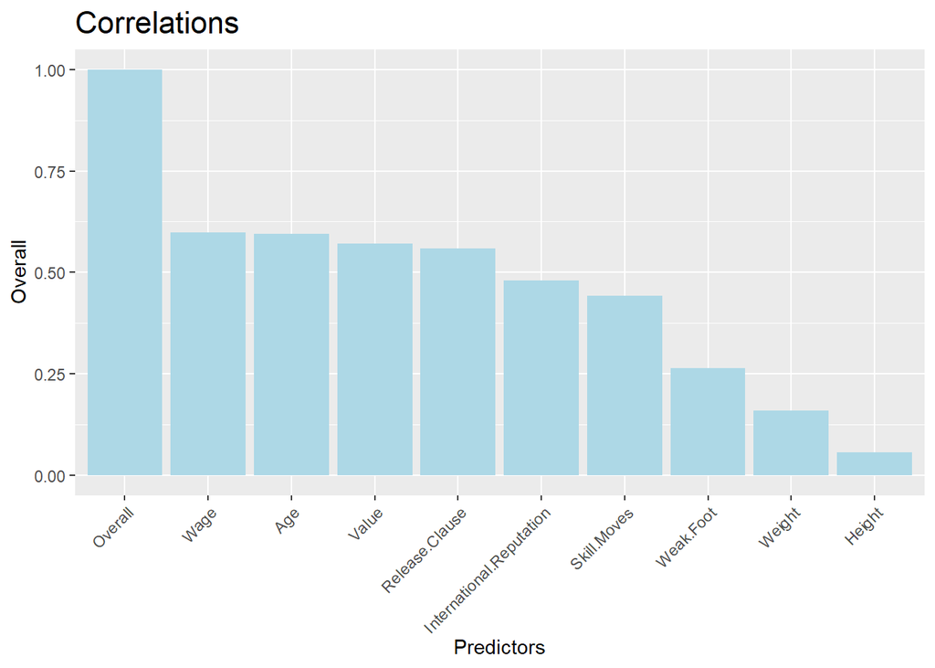

```r
library(leaps)

corr_ <- sort(cor(training[,c(-5,-9)])["Overall",], decreasing = T)
corr=data.frame(corr_)
ggplot(corr,aes(x = row.names(corr), y = corr_)) +
  geom_bar(stat = "identity", fill = "lightblue") +
  scale_x_discrete(limits= row.names(corr)) +
  labs(x = "Predictors", y = "Overall", title = "Correlations") +
  theme(plot.title = element_text(hjust = 0, size = rel(1.5)),
        axis.text.x = element_text(angle = 45, hjust = 1))
```

For that reason we are going to compare them in order to compute the R-squared

```r
linFit <- lm(Overall ~ Age, data= training)
summary(linFit)
```

```
##
## Call:
## lm(formula = Overall ~ Age, data = training)
##
## Residuals:
##      Min       1Q   Median       3Q      Max
## -29.6229  -4.2454  -0.1915   3.8085  27.7546
##
## Coefficients:
##             Estimate Std. Error t value Pr(>|t|)
## (Intercept) 39.62533    0.35215  112.52   <2e-16 ***
## Age          1.02696    0.01494   68.74   <2e-16 ***
## ---
## Signif. codes:  0 '***' 0.001 '**' 0.01 '*' 0.05 '.' 0.1 ' ' 1
##
## Residual standard error: 6.448 on 8589 degrees of freedom
## Multiple R-squared:  0.3549, Adjusted R-squared:  0.3548
## F-statistic:  4725 on 1 and 8589 DF,  p-value: < 2.2e-16
```

As we can see, the R-squared is around 0.4, which means is a weak-medium correlation ship, but it is significant.

Diagnosis:

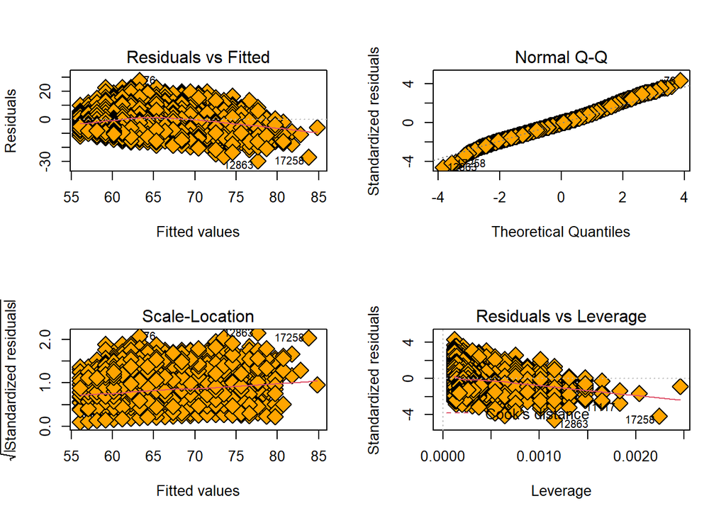

```r
par(mfrow=c(2,2))
plot(linFit, pch=23 ,bg='orange',cex=2)
```

We can see that in the Normal Q-Q we obtained a proportionally direct relationship. Meanwhile in others such as Scale-Location or Residuals vs Fitted there is not a clear relation ship. Lastly, the Residuals vs Leverage we can see a slightly proportionally inverse relation ship between the leverage and the standarizad residuals.

What would happen if we apply logs?

```r
linFit <- lm(log(Overall) ~ log(Age), data=training)
summary(linFit)
```

```
##
## Call:
## lm(formula = log(Overall) ~ log(Age), data = training)
##
## Residuals:
##      Min       1Q   Median       3Q      Max
## -0.46899 -0.06645  0.00137  0.06481  0.36431
##
## Coefficients:
##             Estimate Std. Error t value Pr(>|t|)
## (Intercept) 2.869486   0.017610  162.94   <2e-16 ***
## log(Age)    0.407294   0.005631   72.33   <2e-16 ***
## ---
## Signif. codes:  0 '***' 0.001 '**' 0.01 '*' 0.05 '.' 0.1 ' ' 1
##
## Residual standard error: 0.09932 on 8589 degrees of freedom
## Multiple R-squared:  0.3785, Adjusted R-squared:  0.3784
## F-statistic:  5231 on 1 and 8589 DF,  p-value: < 2.2e-16
```

We can appreciate that the R-squared increased a little bit.

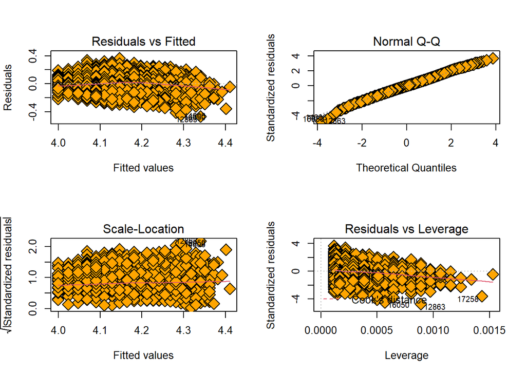

```r
par(mfrow=c(2,2))
plot(linFit, pch=23 ,bg='orange',cex=2)
```

We obtained almost the same result as before.

Predictions:

```r
pr.simple = exp(predict(linFit, newdata=testing))
cor(testing$Overall, pr.simple)^2
```

```
## [1] 0.3656271
```

We obtained around 0.4 of correlation, not a bad model using just one regressor, but it could be much better

## Multiple Regression

```r
linFit <- lm(Overall ~  Age + Value + Wage + International.Reputation + Weak.Foot + Skill.Moves + Height + Weight, data=training)
summary(linFit)
```

```
##
## Call:
## lm(formula = Overall ~ Age + Value + Wage + International.Reputation +
##     Weak.Foot + Skill.Moves + Height + Weight, data = training)
##
## Residuals:
##     Min      1Q  Median      3Q     Max
## -50.869  -3.001   0.286   3.217  17.461
##
## Coefficients:
##                            Estimate Std. Error t value Pr(>|t|)
## (Intercept)               1.915e+01  1.724e+00  11.109  < 2e-16 ***
## Age                       7.560e-01  1.301e-02  58.115  < 2e-16 ***
## Value                     3.147e-07  1.195e-08  26.336  < 2e-16 ***
## Wage                      5.771e-05  4.792e-06  12.045  < 2e-16 ***
## International.Reputation -3.990e-01  1.691e-01  -2.360   0.0183 *
## Weak.Foot                 6.697e-01  8.358e-02   8.013 1.26e-15 ***
## Skill.Moves               2.633e+00  8.314e-02  31.666  < 2e-16 ***
## Height                    7.203e-02  1.194e-02   6.033 1.67e-09 ***
## Weight                    6.494e-02  1.197e-02   5.423 6.01e-08 ***
## ---
## Signif. codes:  0 '***' 0.001 '**' 0.01 '*' 0.05 '.' 0.1 ' ' 1
##
## Residual standard error: 4.78 on 8582 degrees of freedom
## Multiple R-squared:  0.6458, Adjusted R-squared:  0.6455
## F-statistic:  1956 on 8 and 8582 DF,  p-value: < 2.2e-16
```

Prediction

```r
pr.multiple = exp(predict(linFit, newdata=testing))
cor(testing$Overall, pr.multiple)^2
```

```
## [1] 0.003244293
```

## Model Selection

```r
library(leaps)
exhaustive <- regsubsets(Overall ~ Age + Value + Wage + International.Reputation + Weak.Foot + Skill.Moves + Height + Weight, data=training)

summary(exhaustive)
```

```
## Subset selection object
## Call: regsubsets.formula(Overall ~ Age + Value + Wage + International.Reputation +
##     Weak.Foot + Skill.Moves + Height + Weight, data = training)
## 8 Variables  (and intercept)
##                          Forced in Forced out
## Age                          FALSE      FALSE
## Value                        FALSE      FALSE
## Wage                         FALSE      FALSE
## International.Reputation     FALSE      FALSE
## Weak.Foot                    FALSE      FALSE
## Skill.Moves                  FALSE      FALSE
## Height                       FALSE      FALSE
## Weight                       FALSE      FALSE
## 1 subsets of each size up to 8
## Selection Algorithm: exhaustive
##          Age Value Wage International.Reputation Weak.Foot Skill.Moves Height
## 1  ( 1 ) " " " "   "*"  " "                      " "       " "         " "
## 2  ( 1 ) "*" "*"   " "  " "                      " "       " "         " "
## 3  ( 1 ) "*" "*"   " "  " "                      " "       "*"         " "
## 4  ( 1 ) "*" "*"   " "  " "                      " "       "*"         "*"
## 5  ( 1 ) "*" "*"   "*"  " "                      " "       "*"         "*"
## 6  ( 1 ) "*" "*"   "*"  " "                      "*"       "*"         "*"
## 7  ( 1 ) "*" "*"   "*"  " "                      "*"       "*"         "*"
## 8  ( 1 ) "*" "*"   "*"  "*"                      "*"       "*"         "*"
##          Weight
## 1  ( 1 ) " "
## 2  ( 1 ) " "
## 3  ( 1 ) " "
## 4  ( 1 ) " "
## 5  ( 1 ) " "
## 6  ( 1 ) " "
## 7  ( 1 ) "*"
## 8  ( 1 ) "*"
```

Now we plot it

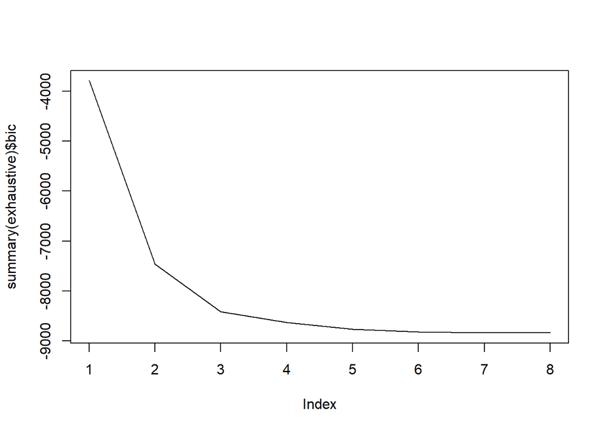

```r
plot(summary(exhaustive)$bic, type = 'l')
```

Alternatively

```r
library(olsrr)

model = Overall ~ Age + Value + Wage + International.Reputation + Weak.Foot + Skill.Moves + Height + Weight

linFit <- lm(model, data=training)

ols_step_all_possible(linFit) # All possible subset regressions: the number is exponential with p
```

```
##     Index N
## 3       1 1
## 1       2 1
## 2       3 1
## 4       4 1
## 6       5 1
## 5       6 1
## 8       7 1
## 7       8 1
## 9       9 2
## 10     10 2
## 13     11 2
## 24     12 2
## 11     13 2
## 19     14 2
```

[output cut: 753 more lines]

The best subset regression for each p: still exponential with p

```r
ols_step_best_subset(linFit)
```

```
##                                  Best Subsets Regression
## ------------------------------------------------------------------------------------------
## Model Index    Predictors
## ------------------------------------------------------------------------------------------
##      1         Wage
##      2         Age Value
##      3         Age Value Skill.Moves
##      4         Age Value Skill.Moves Height
##      5         Age Value Wage Skill.Moves Height
##      6         Age Value Wage Weak.Foot Skill.Moves Height
##      7         Age Value Wage Weak.Foot Skill.Moves Height Weight
##      8         Age Value Wage International.Reputation Weak.Foot Skill.Moves Height Weight
## ------------------------------------------------------------------------------------------
##
##                                                           Subsets Regression Summary
## ----------------------------------------------------------------------------------------------------------------------------------------------
##                        Adj.        Pred
## Model    R-Square    R-Square    R-Square      C(p)          AIC           SBIC          SBC           MSEP          FPE       HSP       APC
## ----------------------------------------------------------------------------------------------------------------------------------------------
##   1        0.3582      0.3581      0.3555    6962.6894    56363.8673    31981.4748    56385.0427    355376.0462    41.3757    0.0048    0.6421
##   2        0.5816      0.5815      0.5793    1552.6334    52690.7570    28309.5932    52718.9909    231714.7010    26.9812    0.0031    0.4187
##   3        0.6259      0.6258      0.6239     480.4768    51730.5497    27349.9254    51765.8421    207186.9571    24.1280    0.0028    0.3744
##   4        0.6356      0.6355      0.6336     247.3185    51506.7075    27126.2354    51549.0583    201834.8519    23.5074    0.0027    0.3648
##   5        0.6418      0.6416      0.6392     100.3977    51362.5537    26982.2294    51411.9630    198453.3105    23.1163    0.0027    0.3587
##   6        0.6444      0.6441      0.6417      39.8637    51302.4325    26922.1886    51358.9003    197046.4331    22.9551    0.0027    0.3562
##   7        0.6456      0.6453      0.6428      12.5702    51275.1773    26894.9818    51338.7035    196399.4466    22.8824    0.0027    0.3551
##   8        0.6458      0.6455      0.6429       9.0000    51271.6030    26891.4200    51342.1877    196294.9274    22.8728    0.0027    0.3549
## ----------------------------------------------------------------------------------------------------------------------------------------------
## AIC: Akaike Information Criteria
##  SBIC: Sawa's Bayesian Information Criteria
##  SBC: Schwarz Bayesian Criteria
##  MSEP: Estimated error of prediction, assuming multivariate normality
##  FPE: Final Prediction Error
##  HSP: Hocking's Sp
##  APC: Amemiya Prediction Criteria
```

Other practical methods when dimension (p/n) is too high

Forward based on AIC

```r
ols_step_forward_aic(linFit)
```

```
##
##                                     Selection Summary
## -----------------------------------------------------------------------------------------
## Variable                       AIC         Sum Sq         RSS         R-Sq      Adj. R-Sq
## -----------------------------------------------------------------------------------------
## Wage                        56363.867    198312.705    355293.314    0.35822      0.35815
## Age                         53259.758    306111.172    247494.847    0.55294      0.55284
## Skill.Moves                 52242.982    333787.263    219818.757    0.60293      0.60279
## Value                       51569.145    350417.256    203188.763    0.63297      0.63280
## Height                      51362.554    355291.320    198314.699    0.64178      0.64157
## Weak.Foot                   51302.433    356720.154    196885.865    0.64436      0.64411
## Weight                      51275.177    357389.477    196216.542    0.64557      0.64528
## International.Reputation    51271.603    357516.750    196089.269    0.64580      0.64547
## -----------------------------------------------------------------------------------------
```

Backward AIC

```r
ols_step_backward_aic(linFit) #
```

```
## [1] "No variables have been removed from the model."
```

stepwise AIC

```r
ols_step_both_aic(linFit)
```

```
##
##
##                                            Stepwise Summary
## -----------------------------------------------------------------------------------------------------
## Variable                     Method        AIC          RSS          Sum Sq       R-Sq      Adj. R-Sq
## -----------------------------------------------------------------------------------------------------
## Wage                        addition    56363.867    355293.314    198312.705    0.35822      0.35815
## Age                         addition    53259.758    247494.847    306111.172    0.55294      0.55284
## Skill.Moves                 addition    52242.982    219818.757    333787.263    0.60293      0.60279
## Value                       addition    51569.145    203188.763    350417.256    0.63297      0.63280
## Height                      addition    51362.554    198314.699    355291.320    0.64178      0.64157
## Weak.Foot                   addition    51302.433    196885.865    356720.154    0.64436      0.64411
## Weight                      addition    51275.177    196216.542    357389.477    0.64557      0.64528
## International.Reputation    addition    51271.603    196089.269    357516.750    0.64580      0.64547
## -----------------------------------------------------------------------------------------------------
```

```r
linFit <- lm(Overall ~ Age + Value + Wage + International.Reputation + Weak.Foot + Skill.Moves + Height + Weight, data=training)
summary(linFit)
```

```
##
## Call:
## lm(formula = Overall ~ Age + Value + Wage + International.Reputation +
##     Weak.Foot + Skill.Moves + Height + Weight, data = training)
##
## Residuals:
##     Min      1Q  Median      3Q     Max
## -50.869  -3.001   0.286   3.217  17.461
##
## Coefficients:
##                            Estimate Std. Error t value Pr(>|t|)
## (Intercept)               1.915e+01  1.724e+00  11.109  < 2e-16 ***
## Age                       7.560e-01  1.301e-02  58.115  < 2e-16 ***
## Value                     3.147e-07  1.195e-08  26.336  < 2e-16 ***
## Wage                      5.771e-05  4.792e-06  12.045  < 2e-16 ***
## International.Reputation -3.990e-01  1.691e-01  -2.360   0.0183 *
## Weak.Foot                 6.697e-01  8.358e-02   8.013 1.26e-15 ***
## Skill.Moves               2.633e+00  8.314e-02  31.666  < 2e-16 ***
## Height                    7.203e-02  1.194e-02   6.033 1.67e-09 ***
## Weight                    6.494e-02  1.197e-02   5.423 6.01e-08 ***
## ---
## Signif. codes:  0 '***' 0.001 '**' 0.01 '*' 0.05 '.' 0.1 ' ' 1
##
## Residual standard error: 4.78 on 8582 degrees of freedom
## Multiple R-squared:  0.6458, Adjusted R-squared:  0.6455
## F-statistic:  1956 on 8 and 8582 DF,  p-value: < 2.2e-16
```

We obtained a R2 close to 65%, which means it is a good model because it explains more or less in a reasonable way the variability of Overall.

## Predictions

```r
predictions <- exp(predict(linFit, newdata=testing))
cor(testing$Overall, predictions)^2
```

```
## [1] 0.003244293
```

```r
RMSE <- sqrt(mean((predictions - testing$Overall)^2))
RMSE
```

```
## [1] 3.883056e+51
```

It is an interesting result because it does not seems reasonable.

## A benchmark

We can compute the mean of the main numerical variable in the training set

```r
mean(training$Overall)
```

```
## [1] 63.35456
```

Which is equivalent to…

```r
benchFit <- lm(Overall ~ 1, data=training)
benchFit$coefficients
```

```
## (Intercept)
##    63.35456
```

```r
predictions <- predict(benchFit, newdata=testing)
RMSE <- sqrt(mean((predictions - testing$Overall)^2))
RMSE
```

```
## [1] 8.129804
```

## Statistical Learning Tools

Let’s use the caret package with CV

```r
ctrl <- trainControl(method = "repeatedcv",
                     number = 5, repeats = 1)
```

```r
linFit <- lm(Overall ~ Age + Value + Wage + International.Reputation + Weak.Foot + Skill.Moves + Height + Weight, data=training)

summary(linFit)
```

```
##
## Call:
## lm(formula = Overall ~ Age + Value + Wage + International.Reputation +
##     Weak.Foot + Skill.Moves + Height + Weight, data = training)
##
## Residuals:
##     Min      1Q  Median      3Q     Max
## -50.869  -3.001   0.286   3.217  17.461
##
## Coefficients:
##                            Estimate Std. Error t value Pr(>|t|)
## (Intercept)               1.915e+01  1.724e+00  11.109  < 2e-16 ***
## Age                       7.560e-01  1.301e-02  58.115  < 2e-16 ***
## Value                     3.147e-07  1.195e-08  26.336  < 2e-16 ***
## Wage                      5.771e-05  4.792e-06  12.045  < 2e-16 ***
## International.Reputation -3.990e-01  1.691e-01  -2.360   0.0183 *
## Weak.Foot                 6.697e-01  8.358e-02   8.013 1.26e-15 ***
## Skill.Moves               2.633e+00  8.314e-02  31.666  < 2e-16 ***
## Height                    7.203e-02  1.194e-02   6.033 1.67e-09 ***
## Weight                    6.494e-02  1.197e-02   5.423 6.01e-08 ***
## ---
## Signif. codes:  0 '***' 0.001 '**' 0.01 '*' 0.05 '.' 0.1 ' ' 1
##
## Residual standard error: 4.78 on 8582 degrees of freedom
## Multiple R-squared:  0.6458, Adjusted R-squared:  0.6455
## F-statistic:  1956 on 8 and 8582 DF,  p-value: < 2.2e-16
```

Consider the following model: It is important to mention that we could include the categorical variables such as Real.Face or Preferred.Foot

```r
ModelS = Overall ~ Real.Face + Preferred.Foot + Age + Wage + International.Reputation*Value + Weak.Foot + Skill.Moves + Height + Weight

ModelF = Overall ~ Real.Face + Preferred.Foot + Age*Skill.Moves + Wage*International.Reputation*Value + Weak.Foot + Weight/Height^2
```

## Linear Regression

```r
lm_tune <- train(ModelS, data = training,
                 method = "lm",
                 preProc=c('scale', 'center'),
                 trControl = ctrl)
lm_tune
```

```
## Linear Regression
##
## 8591 samples
##   10 predictor
##
## Pre-processing: scaled (11), centered (11)
## Resampling: Cross-Validated (5 fold, repeated 1 times)
## Summary of sample sizes: 6872, 6873, 6873, 6872, 6874
## Resampling results:
##
##   RMSE      Rsquared   MAE
##   4.418444  0.6976291  3.481524
##
## Tuning parameter 'intercept' was held constant at a value of TRUE
```

From this point we will start creating a lot of models so it is a good idea to create a data frame which contains all the predictors.

```r
test_results <- data.frame(Overall = testing$Overall)
```

Now we must predict

```r
test_results$lm <- predict(lm_tune, testing)
postResample(pred = test_results$lm,  obs = test_results$Overall)
```

```
##      RMSE  Rsquared       MAE
## 4.5834552 0.6829729 3.5503656
```

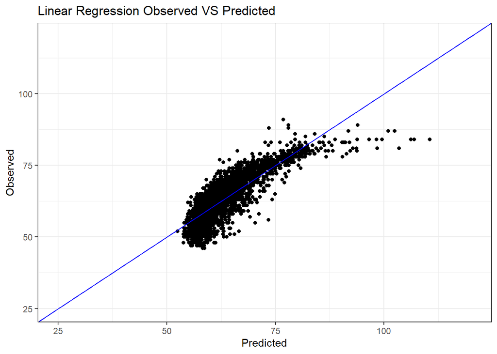

```r
qplot(test_results$lm, test_results$Overall) +
  labs(title="Linear Regression Observed VS Predicted", x="Predicted", y="Observed") +
  lims(x = c(25, 120), y = c(25, 120)) +
  geom_abline(intercept = 0, slope = 1, colour = "blue") +
  theme_bw()
```

We can see that the result are quite good and there is a very low bias because most of the points are together in the straight line and also there is a very low variance because most of the points are together (except some at the most right part). So that is something good because at the end of the day we want to avoid high bias and high variability because it affects our predictions and makes worse our model.

## Overfitted linear regression

We start by training our model

```r
alm_tune <- train(ModelS, data = training,
                  method = "lm",
                  preProc=c('scale', 'center'),
                  trControl = ctrl)
```

And now predict

```r
test_results$alm <- predict(alm_tune, testing)
postResample(pred = test_results$alm,  obs = test_results$Overall)
```

```
##      RMSE  Rsquared       MAE
## 4.5834552 0.6829729 3.5503656
```

Visualization

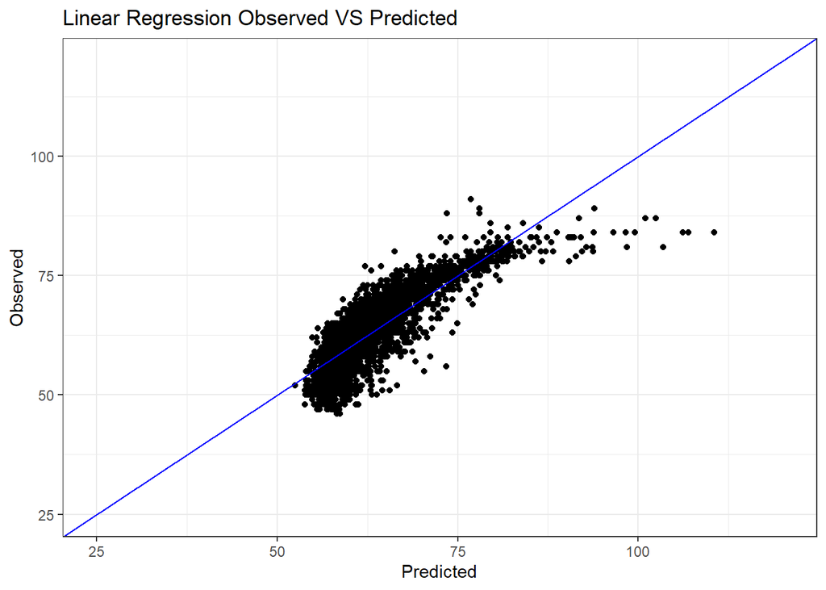

```r
qplot(test_results$alm, test_results$Overall) +
  labs(title="Linear Regression Observed VS Predicted", x="Predicted", y="Observed") +
  lims(x = c(25,120), y = c(25,120)) +
  geom_abline(intercept = 0, slope = 1, colour = "blue") +
  theme_bw()
```

Visually it looks quite similar to the previous plot without the ovefitted linear regression, so probably this model it is not the most recommended.

## Forward regression

We start by training our model

```r
for_tune <- train(ModelS, data = training,
                  method = "leapForward",
                  preProc=c('scale', 'center'),
                  tuneGrid = expand.grid(nvmax = 4:10),
                  trControl = ctrl)

for_tune
```

```
## Linear Regression with Forward Selection
##
## 8591 samples
##   10 predictor
##
## Pre-processing: scaled (11), centered (11)
## Resampling: Cross-Validated (5 fold, repeated 1 times)
## Summary of sample sizes: 6872, 6873, 6873, 6873, 6873
## Resampling results across tuning parameters:
##
##   nvmax  RMSE      Rsquared   MAE
##    4     4.830308  0.6387007  3.765823
##    5     4.541363  0.6810601  3.546783
##    6     4.501685  0.6865398  3.525354
##    7     4.463560  0.6917864  3.508700
##    8     4.450099  0.6936846  3.498217
##    9     4.440022  0.6950382  3.494238
##   10     4.434462  0.6957866  3.487472
##
## RMSE was used to select the optimal model using the smallest value.
## The final value used for the model was nvmax = 10.
```

Plot it

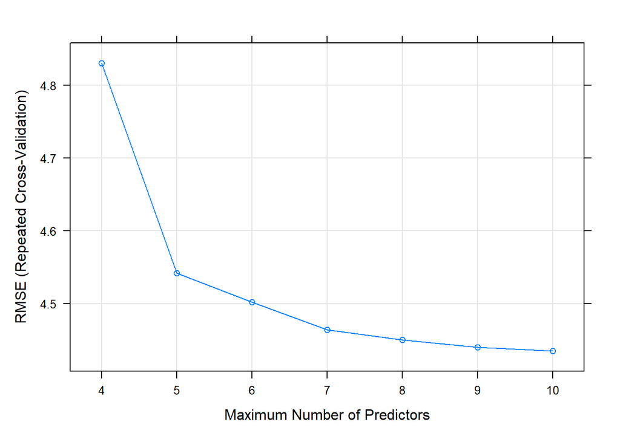

```r
plot(for_tune)
```

```r
coef(for_tune$finalModel, for_tune$bestTune$nvmax)
```

```
##                    (Intercept)                     Real.Face1
##                     63.3545571                      0.3777249
##                Preferred.Foot2                            Age
##                     -0.2365643                      3.1463665
##                           Wage       International.Reputation
##                      1.1466611                      0.6722240
##                          Value                      Weak.Foot
##                      6.3357860                      0.4099450
##                    Skill.Moves                         Weight
##                      1.5984810                      0.6931004
## International.Reputation:Value
##                     -4.7422530
```

Predict

```r
test_results$frw <- predict(for_tune, testing)
postResample(pred = test_results$frw,  obs = test_results$Overall)
```

```
##      RMSE  Rsquared       MAE
## 4.5932662 0.6816173 3.5531357
```

Again we obtain a Rsquared of 0.69 which is a good model because it is almost 70% of the variability of Overall explained.

Visualization

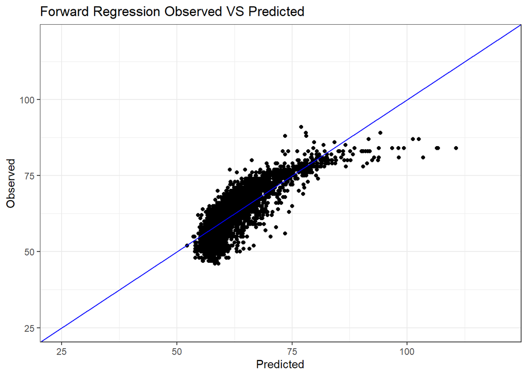

```r
qplot(test_results$frw, test_results$Overall) +
  labs(title="Forward Regression Observed VS Predicted", x="Predicted", y="Observed") +
  lims(x = c(25,120), y = c(25,120)) +
  geom_abline(intercept = 0, slope = 1, colour = "blue") +
  theme_bw()
```

Once again, we obtain a plot quite similar to the previous ones, where the bias and the variability are very low and there are some outliers at the right.

## Backward regression

Again, we start training the model

```r
back_tune <- train(ModelS, data = training,
                   method = "leapBackward",
                   preProc=c('scale', 'center'),
                   tuneGrid = expand.grid(nvmax = 4:10),
                   trControl = ctrl)
back_tune
```

```
## Linear Regression with Backwards Selection
##
## 8591 samples
##   10 predictor
##
## Pre-processing: scaled (11), centered (11)
## Resampling: Cross-Validated (5 fold, repeated 1 times)
## Summary of sample sizes: 6873, 6871, 6873, 6873, 6874
## Resampling results across tuning parameters:
##
##   nvmax  RMSE      Rsquared   MAE
##    4     4.620738  0.6693856  3.626896
##    5     4.542036  0.6805793  3.549588
##    6     4.502091  0.6861494  3.530397
##    7     4.465808  0.6911324  3.513276
##    8     4.452389  0.6930102  3.502899
##    9     4.442098  0.6944566  3.498016
##   10     4.435322  0.6953813  3.490020
##
## RMSE was used to select the optimal model using the smallest value.
## The final value used for the model was nvmax = 10.
```

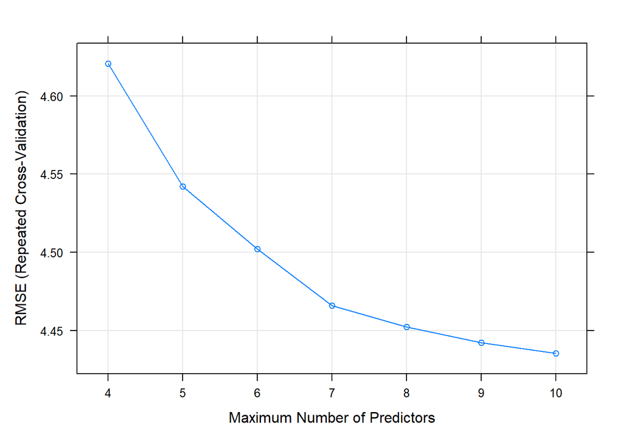

```r
plot(back_tune)
```

```r
coef(back_tune$finalModel, back_tune$bestTune$nvmax)
```

```
##                    (Intercept)                     Real.Face1
##                     63.3545571                      0.3777249
##                Preferred.Foot2                            Age
##                     -0.2365643                      3.1463665
##                           Wage       International.Reputation
##                      1.1466611                      0.6722240
##                          Value                      Weak.Foot
##                      6.3357860                      0.4099450
##                    Skill.Moves                         Weight
##                      1.5984810                      0.6931004
## International.Reputation:Value
##                     -4.7422530
```

We predict

```r
test_results$bw <- predict(back_tune, testing)
postResample(pred = test_results$bw,  obs = test_results$Overall)
```

```
##      RMSE  Rsquared       MAE
## 4.5932662 0.6816173 3.5531357
```

Visualize

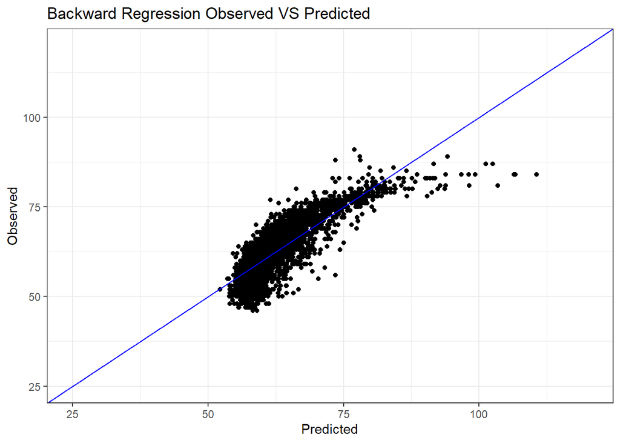

```r
qplot(test_results$bw, test_results$Overall) +
  labs(title="Backward Regression Observed VS Predicted", x="Predicted", y="Observed") +
  lims(x = c(25, 120), y = c(25, 120)) +
  geom_abline(intercept = 0, slope = 1, colour = "blue") +
  theme_bw()
```

# Ridge Regression

```r
# X matrix
X = model.matrix(ModelF, data=training)[,-1]  # skip column of ones

# y variable
y = log(training$Overall)
```

Now we need to define a grid for the penalty hyper-parameter lambda

```r
grid = seq(0, .1, length = 100)  # a 100-size grid for lambda (rho in slides)
```

Estimate the ridge regression for all the penalties defined in the grid. The algorithm is extremely fast

```r
ridge.mod = glmnet(X, y, alpha=0, lambda=grid)  # alpha=0 for ridge regression
```

Remember ridge regression is shrinking only beta’s associated with variables, not β0

```r
dim(coef(ridge.mod))
```

```
## [1]  16 100
```

```r
coef(ridge.mod)
```

```
## 16 x 100 sparse Matrix of class "dgCMatrix"
##
## (Intercept)                          3.775084e+00  3.774273e+00  3.773452e+00
## Real.Face1                           3.563203e-02  3.567400e-02  3.569697e-02
## Preferred.Foot2                     -6.465109e-03 -6.487267e-03 -6.509149e-03
## Age                                  5.269653e-03  5.289376e-03  5.308908e-03
## Skill.Moves                          1.595638e-02  1.598725e-02  1.601721e-02
## Wage                                 7.820641e-07  7.847530e-07  7.881020e-07
## International.Reputation             1.284567e-02  1.277092e-02  1.271215e-02
## Value                                2.403144e-09  2.414819e-09  2.427646e-09
## Weak.Foot                            1.014103e-02  1.015587e-02  1.017206e-02
## Weight                               8.640682e-04  8.656879e-04  8.671576e-04
## Age:Skill.Moves                      7.573274e-04  7.583490e-04  7.593902e-04
## Wage:International.Reputation        3.623063e-08  3.578647e-08  3.526886e-08
## Wage:Value                          -2.816823e-15 -2.850474e-15 -2.893597e-15
## International.Reputation:Value       1.731798e-10  1.731030e-10  1.727764e-10
## Weight:Height                        3.447553e-06  3.456744e-06  3.466133e-06
## Wage:International.Reputation:Value -1.508614e-15 -1.521725e-15 -1.534651e-15
##
## (Intercept)                          3.772631e+00  3.771809e+00  3.770983e+00
## Real.Face1                           3.571560e-02  3.573431e-02  3.575239e-02
## Preferred.Foot2                     -6.531244e-03 -6.553510e-03 -6.575916e-03
## Age                                  5.328421e-03  5.348151e-03  5.368094e-03
## Skill.Moves                          1.604530e-02  1.607341e-02  1.610174e-02
## Wage                                 7.914133e-07  7.947398e-07  7.981204e-07
## International.Reputation             1.265167e-02  1.258880e-02  1.252464e-02
## Value                                2.440931e-09  2.454347e-09  2.467956e-09
## Weak.Foot                            1.018852e-02  1.020492e-02  1.022133e-02
## Weight                               8.686455e-04  8.701255e-04  8.715938e-04
## Age:Skill.Moves                      7.604834e-04  7.615687e-04  7.626415e-04
## Wage:International.Reputation        3.478859e-08  3.430246e-08  3.380507e-08
## Wage:Value                          -2.936488e-15 -2.979696e-15 -3.023689e-15
## International.Reputation:Value       1.723947e-10  1.720291e-10  1.716578e-10
## Weight:Height                        3.475507e-06  3.484930e-06  3.494401e-06
## Wage:International.Reputation:Value -1.548027e-15 -1.561559e-15 -1.575221e-15
##
## (Intercept)                          3.770153e+00  3.769320e+00  3.768484e+00
## Real.Face1                           3.576954e-02  3.578578e-02  3.580110e-02
## Preferred.Foot2                     -6.598468e-03 -6.621168e-03 -6.644017e-03
## Age                                  5.388241e-03  5.408597e-03  5.429166e-03
```

[output cut: 524 more lines]

```
## Real.Face1                           7.791000e-04
## Preferred.Foot2                     -7.993421e-03
## Age                                  1.605288e-02
## Skill.Moves                          9.093611e-02
## Wage                                 3.648509e-06
## International.Reputation             3.029400e-02
## Value                                1.778004e-08
## Weak.Foot                            8.517079e-03
## Weight                              -4.910726e-04
## Age:Skill.Moves                     -2.553511e-03
## Wage:International.Reputation       -7.986283e-07
## Wage:Value                          -1.572579e-13
## International.Reputation:Value      -4.238464e-09
## Weight:Height                        8.023609e-06
## Wage:International.Reputation:Value  3.983997e-14
```

By plotting the solution path

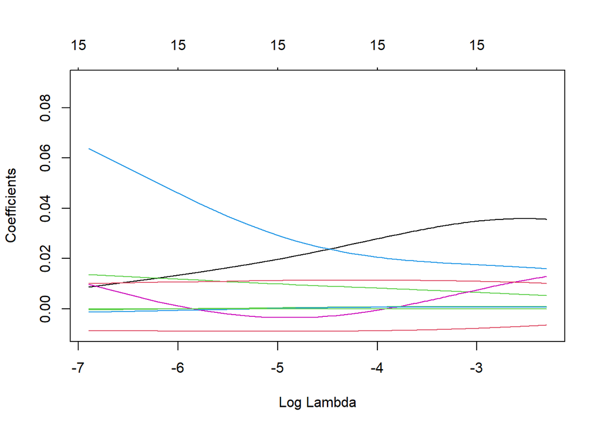

```r
plot(ridge.mod, xvar="lambda")
```

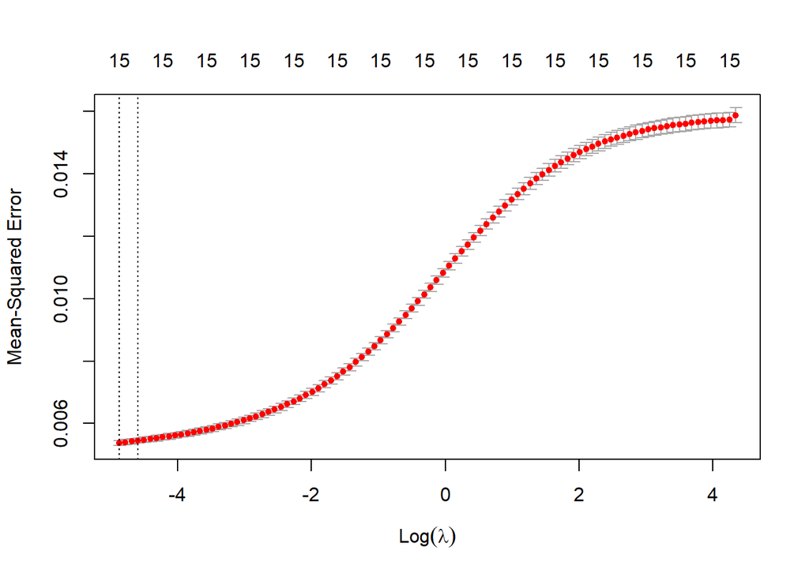

```r
ridge.cv = cv.glmnet(X, y, type.measure="mse", alpha=0)
plot(ridge.cv)
```

The lowest point in the curve indicates the optimal lambda: the log value of lambda that best minimised the error in cross-validation

So we are going to compute the optimal landa

```r
opt.lambda <- ridge.cv$lambda.min
opt.lambda
```

```
## [1] 0.007644257
```

We find out that the value of lambda should be 0.007

In order to estimate the betas and lambdas, we could apply the following method (1se):

```r
lambda.index <- which(ridge.cv$lambda == ridge.cv$lambda.1se)
beta.ridge <- ridge.cv$glmnet.fit$beta[, lambda.index]
beta.ridge
```

```
##                          Real.Face1                     Preferred.Foot2
##                        2.292509e-02                       -8.891683e-03
##                                 Age                         Skill.Moves
##                        9.267764e-03                        2.478084e-02
##                                Wage            International.Reputation
##                        1.682216e-06                       -3.140009e-03
##                               Value                           Weak.Foot
##                        6.306786e-09                        1.138534e-02
##                              Weight                     Age:Skill.Moves
##                        6.121157e-04                        4.248725e-04
##       Wage:International.Reputation                          Wage:Value
##                       -1.212815e-07                       -2.134185e-14
##      International.Reputation:Value                       Weight:Height
##                       -1.576396e-10                        5.011531e-06
## Wage:International.Reputation:Value
##                       -1.754657e-15
```

Prediction

```r
X.test = model.matrix(ModelF, data=testing)[,-1]  # skip column of ones

ridge.pred = predict(ridge.cv$glmnet.fit, s=opt.lambda, newx=X.test)
```

To visualize the performance, we can use the postResample function in caret

```r
y.test = log(testing$Overall)

postResample(pred = ridge.pred,  obs = y.test)
```

```
##       RMSE   Rsquared        MAE
## 0.07429496 0.66265684 0.05869489
```

And using Caret…

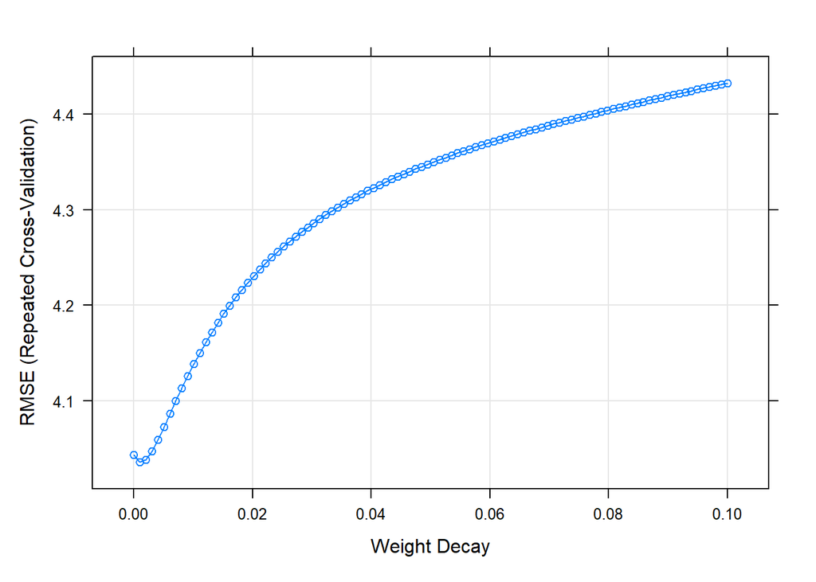

```r
library(elasticnet)
# the grid for lambda
ridge_grid <- expand.grid(lambda = seq(0, .1, length = 100))

# train
ridge_tune <- train(ModelF, data = training,
                    method='ridge',
                    preProc=c('scale','center'),
                    tuneGrid = ridge_grid,
                    trControl=ctrl)
plot(ridge_tune)
```

```r
# the best tune
ridge_tune$bestTune
```

```
##        lambda
## 2 0.001010101
```

```r
# prediction
test_results$ridge <- predict(ridge_tune, testing)

postResample(pred = test_results$ridge,  obs = test_results$Overall)
```

```
##      RMSE  Rsquared       MAE
## 4.1325085 0.7418889 3.2198176
```

## The Lasso

Lets compute it directly with Caret

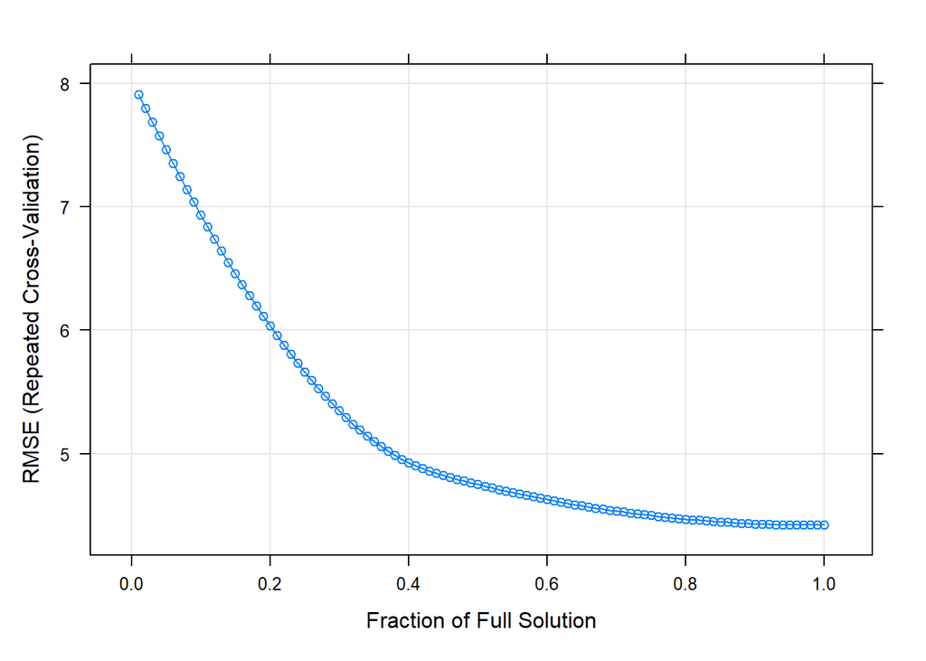

```r
lasso_grid <- expand.grid(fraction = seq(.01, 1, length = 100))

lasso_tune <- train(ModelS, data = training,
                    method='lasso',
                    preProc=c('scale','center'),
                    tuneGrid = lasso_grid,
                    trControl=ctrl)
plot(lasso_tune)
```

```r
lasso_tune$bestTune
```

```
##    fraction
## 98     0.98
```

```r
test_results$lasso <- predict(lasso_tune, testing)
postResample(pred = test_results$lasso,  obs = test_results$Overall)
```

```
##      RMSE  Rsquared       MAE
## 4.5772067 0.6835808 3.5523117
```

Some insights that we could obtain from this tool is that we obtain a good model that it looks it is not neither under fitted or over fitted because the rsquared is approximately 0.7.

## Elastic Net

Lets start by cheking the names for the hyper-parameters

```r
modelLookup('glmnet')
```

```
##    model parameter                    label forReg forClass probModel
## 1 glmnet     alpha        Mixing Percentage   TRUE     TRUE      TRUE
## 2 glmnet    lambda Regularization Parameter   TRUE     TRUE      TRUE
```

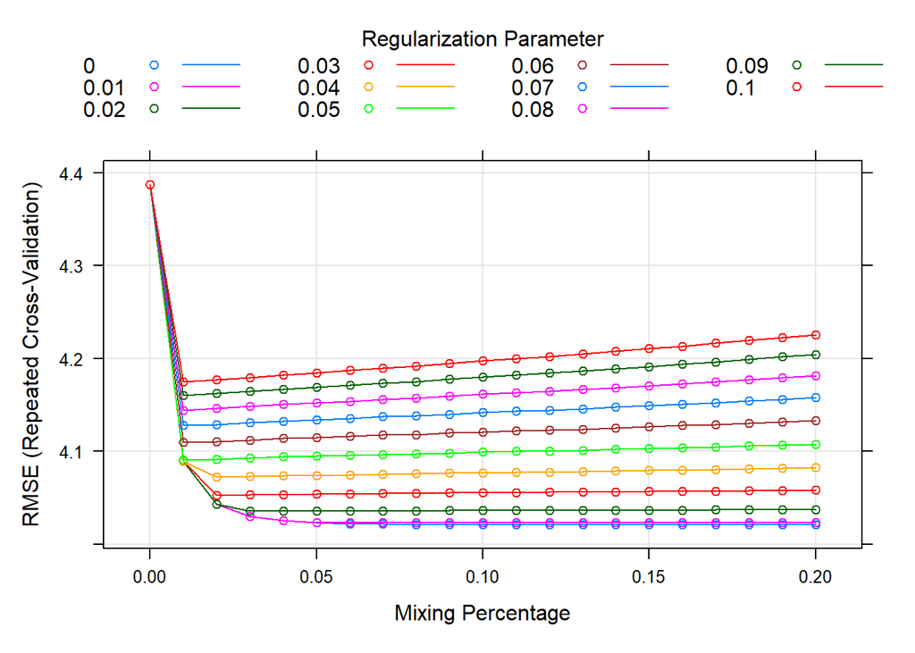

```r
elastic_grid = expand.grid(alpha = seq(0, .2, 0.01), lambda = seq(0, .1, 0.01))

glmnet_tune <- train(ModelF, data = training,
                     method='glmnet',
                     preProc=c('scale','center'),
                     tuneGrid = elastic_grid,
                     trControl=ctrl)

plot(glmnet_tune)
```

We can see in the graph that we obtain lines that are very close one to the other and a possible “outlier”

```r
glmnet_tune$bestTune
```

```
##     alpha lambda
## 111   0.1      0
```

# Machine Learning Tools

## KNN

Lets have a look on the hyper parameters names

```r
modelLookup('kknn')
```

```
##   model parameter           label forReg forClass probModel
## 1  kknn      kmax Max. #Neighbors   TRUE     TRUE      TRUE
## 2  kknn  distance        Distance   TRUE     TRUE      TRUE
## 3  kknn    kernel          Kernel   TRUE     TRUE      TRUE
```

3 hyper-parameters: kmax, distance, kernel # kmax: number of neighbors considered # distance: parameter of Minkowski distance (p in Lp) # kernel: “rectangular” (standard unweighted knn), “triangular”, “epanechnikov” (or beta(2,2)), “biweight” (or beta(3,3)), “tri- weight” (or beta(4,4)), “cos”, “inv”, “gaussian”, “rank” and “optimal”.

Now we should train. Because Machine Learning models are non-linear we can use simpler formulas

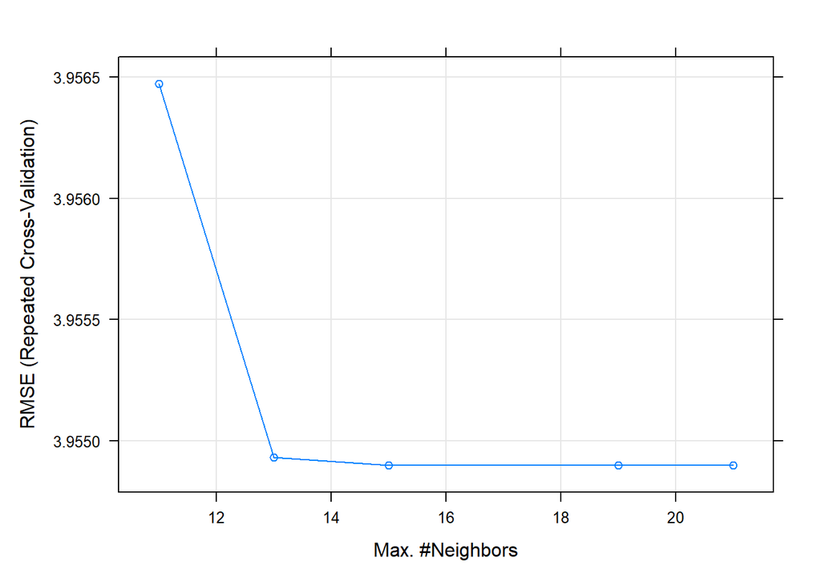

```r
library(kknn)
library(igraph)

knn_tune <- train(ModelS,
                  data = training,
                  method = "kknn",
                  preProc=c('scale','center'),
                  tuneGrid = data.frame(kmax=c(11,13,15,19,21),distance=2,kernel='optimal'),
                  trControl = ctrl)
plot(knn_tune)
```

This process is quite PC-resource demanding.

```r
test_results$knn <- predict(knn_tune, testing)

postResample(pred = test_results$knn,  obs = test_results$Overall)
```

```
##      RMSE  Rsquared       MAE
## 3.9206453 0.7704823 3.0202772
```

## Random Forest

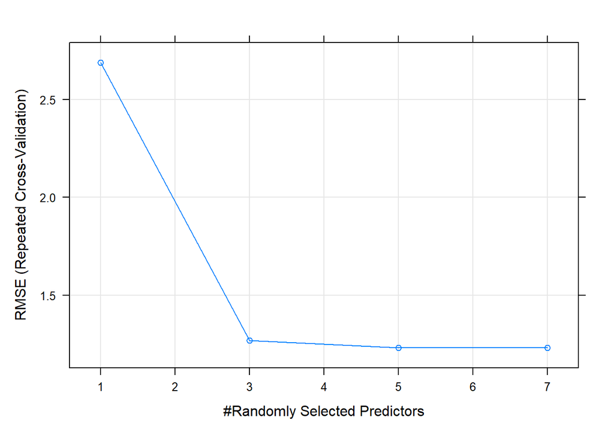

```r
rf_tune <- train(ModelS,
                 data = training,
                 method = "rf",
                 preProc=c('scale','center'),
                 trControl = ctrl,
                 ntree = 100,
                 tuneGrid = data.frame(mtry=c(1,3,5,7)),
                 importance = TRUE)

plot(rf_tune)
```

```r
test_results$rf <- predict(rf_tune, testing)

postResample(pred = test_results$rf,  obs = test_results$Overall)
```

```
##      RMSE  Rsquared       MAE
## 1.2240986 0.9774623 0.7124011
```

We have obtained a Rsquared of 97.7% which is almost a perfect regression, however, it is important to take into consideration that maybe we are over fitting too much the model.

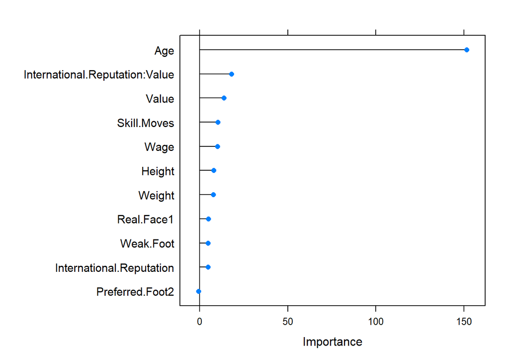

```r
plot(varImp(rf_tune, scale = F), scales = list(y = list(cex = .95)))
```

As we can see, the most important variable is the Age, which is extremely significant compared to the other variables.

## Gradient Boosting

```r
xgb_tune <- train(ModelS,
                  data = training,
                  method = "xgbTree",
                  preProc=c('scale','center'),
                  objective="reg:squarederror",
                  trControl = ctrl,
                  tuneGrid = expand.grid(nrounds = c(500,1000), max_depth = c(5,6,7), eta = c(0.01, 0.1, 1),
                                         gamma = c(1, 2, 3), colsample_bytree = c(1, 2),
                                         min_child_weight = c(1), subsample = c(0.2,0.5,0.8)))
```

[output not shown]

[output cut: 350 more lines]

[output not shown]

```r
test_results$xgb <- predict(xgb_tune, testing)

postResample(pred = test_results$xgb,  obs = test_results$Overall)
```

```
##      RMSE  Rsquared       MAE
## 1.1821048 0.9789036 0.6795036
```

## Ensemble

Let’s summarize the MAE for all the tools

```r
apply(test_results[-1], 2, function(x) mean(abs(x - test_results$Overall)))
```

```
##        lm       alm       frw        bw     ridge     lasso       knn        rf
## 3.5503656 3.5503656 3.5531357 3.5531357 3.2198176 3.5523117 3.0202772 0.7124011
##       xgb
## 0.6795036
```

```r
# Combination
test_results$comb = (test_results$alm + test_results$knn + test_results$rf)/3

postResample(pred = test_results$comb,  obs = test_results$Overall)
```

```
##      RMSE  Rsquared       MAE
## 2.8268977 0.8864766 2.1890695
```

We obtain a R2 of 0.88 which is quite good compared to previous tools and also it does not seem like it is over fitted, so Ensemble is an interesting option in order to apply regression.

## Final Predictions

```r
yhat = exp(test_results$comb)

head(yhat) # show the prediction for 6 home prices
```

```
## [1] 1.936688e+37 5.052163e+37 1.729043e+40 4.946308e+37 1.867076e+39
## [6] 4.333819e+36
```

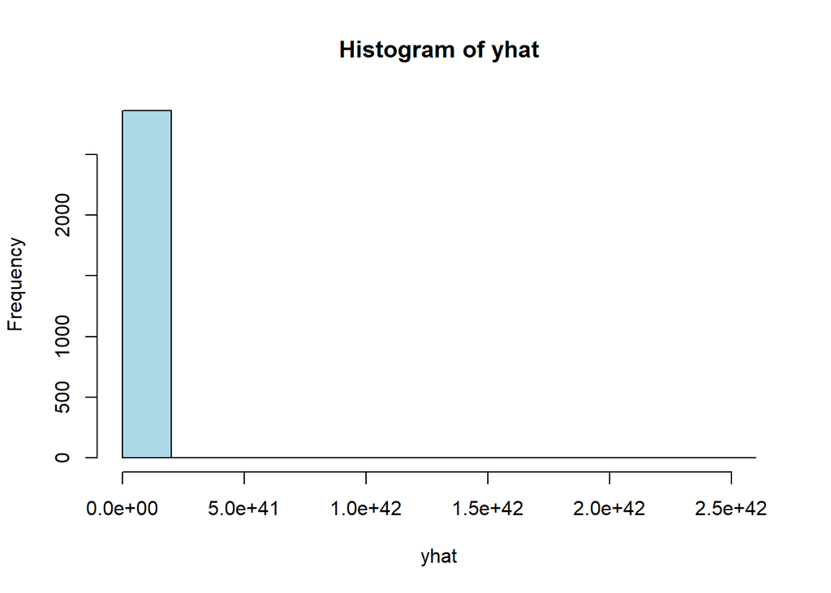

```r
hist(yhat, col="lightblue")
```

# Conclusion

After completing this Homework, I had applied a lot of different supervised learning tools for classification and regression. We had work with bivariable classes and multinomial classes in classification and also to obtain optimal hyper parameters and tresholds. Classification has been very useful in order to understand the importance of how categorical variables can be predict depending on other variables without necessary been highly correlated. It was very interesting to focus on just one categorical variable and apply methods such as LDA or QDA which gives us useful information about the data set and in order to predict.

For regression it was also quite interesting to try to predict by training a model and testing it in order to obtain the best model that represent in the best way the data. Also for regression it was quite interesting to try to produce a own model (modelS or modelF) just by applying feature engineering in order to find the correlations between variables in order to obtain the best model as possible.

We have applied common tools in classification and regression such as Random Forests, which can be approached in order to apply classification or regression.

It is important to mention the data set, which, as we can suppose it is essential to have a big data set in order to obtain realistic results, which I consider that has been my case, I choose a huge data set in order to predict and obtain the best possible models. For the previous home work that was about unsupervised learning tools I also choose this data set because I consider it is the enough diverse and big to can study it in different ways, by applying either supervised or unsupervised learning tools. As I recommended in my work, it would be interesting to apply supervised learning tools, and I finally did it.

I decided to make most of the tools available because I wanted to learn as much as possible about supervised learning tools and in order to have the knowledge in order to be able to apply it by my self.